# Final Project

Team Hyssop

2025-03-12

# Data Preprocessing

## Loading the packages

```r
library(vars)
library(tseries)
library(forecast)
library(readxl)
library(dplyr)
library(lubridate)
library(tidyr)
library(Metrics)
```

```r
library(ggplot2)
library(reshape2)
library(tidyverse)
library(lmtest)
```

## Loading the dataset

```r
data <- read_excel("data.xlsx")
head(data)
```

```
## # A tibble: 6 × 9
##   Date                `Crude Oil (Dollars per Barrel)` Retail Gasoline Prices …¹
##   <dttm>                                         <dbl>                     <dbl>
## 1 1993-04-01 00:00:00                             20.2                      1.08
## 2 1993-05-01 00:00:00                             20.0                      1.10
## 3 1993-06-01 00:00:00                             19.1                      1.10
## 4 1993-07-01 00:00:00                             17.9                      1.08
## 5 1993-08-01 00:00:00                             18.0                      1.06
## 6 1993-09-01 00:00:00                             17.5                      1.05
## # ℹ abbreviated name: ¹`Retail Gasoline Prices (Dollars per Gallon)`
## # ℹ 6 more variables:
## #   `U.S. Percent Utilization of Refinery Operable Capacity %` <dbl>,
## #   `Avg of US Ending Stock of Motor Gasoline` <dbl>,
## #   `Average of U.S. Ending Stocks excluding SPR of Crude Oil` <dbl>,
## #   `U.S. Product Supplied of Finished Motor Gasoline` <dbl>,
## #   `Heating Degree Days` <dbl>, `Cooling Degree Days` <dbl>
```

```r
data <- data %>%
  mutate(Date = as.Date(Date))
```

```r
head(data$Date)
```

```
## [1] "1993-04-01" "1993-05-01" "1993-06-01" "1993-07-01" "1993-08-01"
## [6] "1993-09-01"
```

```r
head(data)
```

```
## # A tibble: 6 × 9
##   Date       `Crude Oil (Dollars per Barrel)` Retail Gasoline Prices (Dollars …¹
##   <date>                                <dbl>                              <dbl>
## 1 1993-04-01                             20.2                               1.08
## 2 1993-05-01                             20.0                               1.10
## 3 1993-06-01                             19.1                               1.10
## 4 1993-07-01                             17.9                               1.08
## 5 1993-08-01                             18.0                               1.06
## 6 1993-09-01                             17.5                               1.05
## # ℹ abbreviated name: ¹`Retail Gasoline Prices (Dollars per Gallon)`
## # ℹ 6 more variables:
## #   `U.S. Percent Utilization of Refinery Operable Capacity %` <dbl>,
## #   `Avg of US Ending Stock of Motor Gasoline` <dbl>,
## #   `Average of U.S. Ending Stocks excluding SPR of Crude Oil` <dbl>,
## #   `U.S. Product Supplied of Finished Motor Gasoline` <dbl>,
## #   `Heating Degree Days` <dbl>, `Cooling Degree Days` <dbl>
```

```r
str(data)
```

```
## tibble [380 × 9] (S3: tbl_df/tbl/data.frame)
##  $ Date                                                    : Date[1:380], format: "1993-04-01" "1993-05-01" ...
##  $ Crude Oil (Dollars per Barrel)                          : num [1:380] 20.2 19.9 19.1 17.9 18 ...
##  $ Retail Gasoline Prices (Dollars per Gallon)             : num [1:380] 1.08 1.1 1.1 1.08 1.06 ...
##  $ U.S. Percent Utilization of Refinery Operable Capacity %: num [1:380] 85.5 89.4 92.4 91.9 89.1 90.7 89.3 90.1 87.5 86.8 ...
##  $ Avg of US Ending Stock of Motor Gasoline                : num [1:380] 185153 183072 187002 179334 169446 ...
##  $ Average of U.S. Ending Stocks excluding SPR of Crude Oil: num [1:380] 3.28e+08 3.34e+08 3.33e+08 3.37e+08 3.29e+08 ...
##  $ U.S. Product Supplied of Finished Motor Gasoline        : num [1:380] 7435000 7585000 7700000 7785000 7864000 ...
##  $ Heating Degree Days                                     : num [1:380] 386 143 44 14 12 ...
##  $ Cooling Degree Days                                     : num [1:380] 18 87 196 334 304 139 44 12 5 7 ...
```

```r
# Check for missing values
sum(is.na(data))
```

```
## [1] 0
```

```r
colSums(is.na(data))
```

```
##                                                     Date
##                                                        0
##                           Crude Oil (Dollars per Barrel)
##                                                        0
##              Retail Gasoline Prices (Dollars per Gallon)
##                                                        0
## U.S. Percent Utilization of Refinery Operable Capacity %
##                                                        0
##                 Avg of US Ending Stock of Motor Gasoline
##                                                        0
## Average of U.S. Ending Stocks excluding SPR of Crude Oil
##                                                        0
##         U.S. Product Supplied of Finished Motor Gasoline
##                                                        0
##                                      Heating Degree Days
##                                                        0
##                                      Cooling Degree Days
##                                                        0
```

```r
# Convert to time series (monthly data)
crude_ts <- ts(data$`Crude Oil (Dollars per Barrel)`, frequency = 12, start = c(year(min(data$Date)), month(min(data$Date))))
gasoline_ts <- ts(data$`Retail Gasoline Prices (Dollars per Gallon)`, frequency = 12, start = c(year(min(data$Date)), month(min(data$Date))))
```

## Splitting into training and testing

```r
# Training data (1993-04-01 to 2023-12-01)
train_crude <- window(crude_ts, start = c(1993, 4), end = c(2023, 12))
train_gasoline <- window(gasoline_ts, start = c(1993, 4), end = c(2023, 12))

# Testing data (2024-01-01 to 2024-11-01)
test_crude <- window(crude_ts, start = c(2024, 1), end = c(2024, 11))
test_gasoline <- window(gasoline_ts, start = c(2024, 1), end = c(2024, 11))
```

# Exploratory Data Analysis

## Plotting the times series data

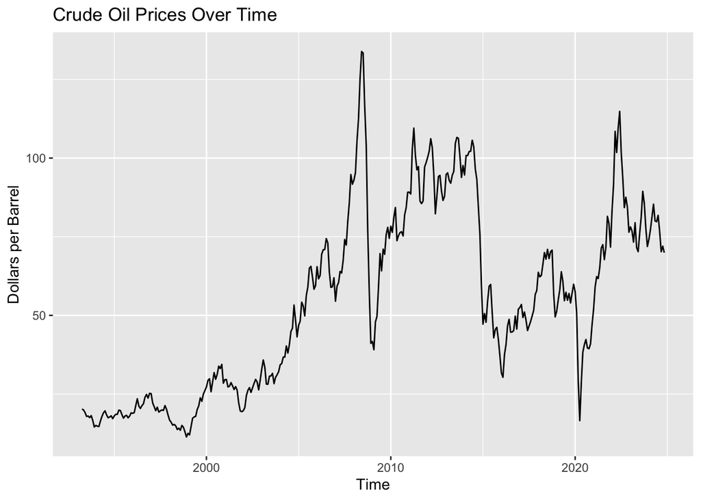

```r
# Plot Crude Oil Prices
autoplot(crude_ts) +
  labs(title = "Crude Oil Prices Over Time", y = "Dollars per Barrel")
```

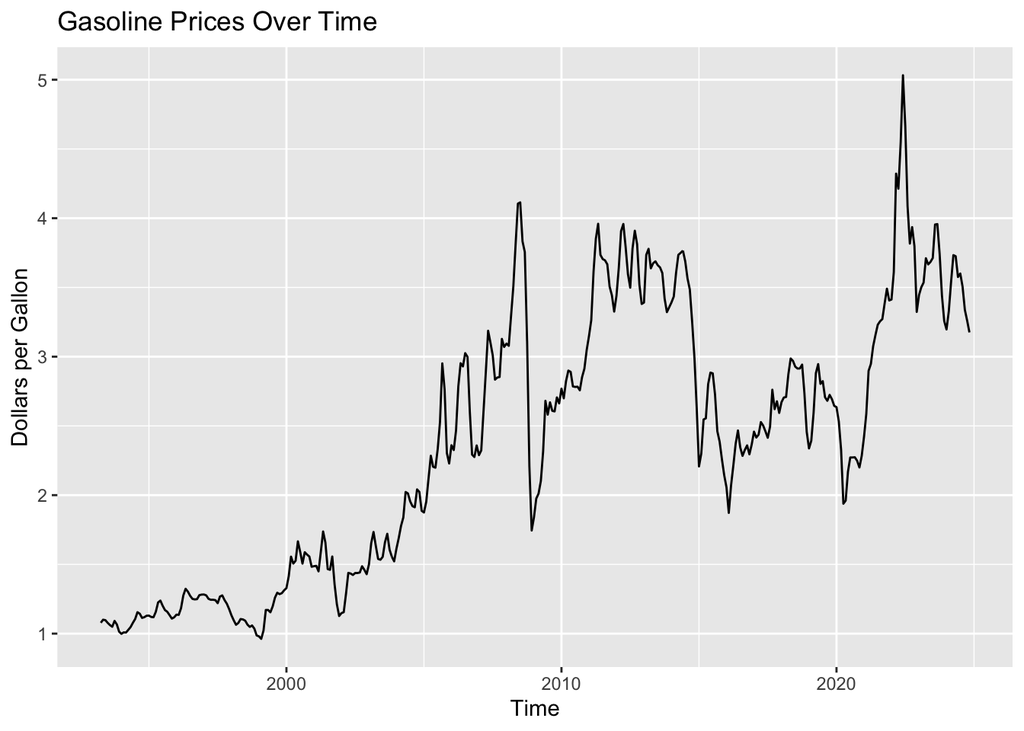

```r
# Plot Gasoline Prices
autoplot(gasoline_ts) +
  labs(title = "Gasoline Prices Over Time", y = "Dollars per Gallon")
```

## Checking for stationarity

```r
# ADF test for Crude Oil Prices
adf_crude <- adf.test(na.omit(crude_ts))
print(adf_crude)
```

```
##
##  Augmented Dickey-Fuller Test
##
## data:  na.omit(crude_ts)
## Dickey-Fuller = -2.5724, Lag order = 7, p-value = 0.3354
## alternative hypothesis: stationary
```

```r
# ADF test for Gasoline Prices
adf_gasoline <- adf.test(na.omit(gasoline_ts))
print(adf_gasoline)
```

```
##
##  Augmented Dickey-Fuller Test
##
## data:  na.omit(gasoline_ts)
## Dickey-Fuller = -2.4815, Lag order = 7, p-value = 0.3738
## alternative hypothesis: stationary
```

### Inference

Both crude oil prices and gasoline prices are non-stationary (p-values > 0.05). This means:

1. Their means and variances change over time.
2. Modeling them directly (e.g., with ARIMA or linear regression) could lead to spurious results.

## Checking for Co-integration

```r
# Cointegration test (Engle-Granger)
coint_test <- lm(`Retail Gasoline Prices (Dollars per Gallon)` ~ `Crude Oil (Dollars per Barrel)`, data = data)
spread <- residuals(coint_test)
adf_spread <- adf.test(na.omit(spread))
print(adf_spread)
```

```
##
##  Augmented Dickey-Fuller Test
##
## data:  na.omit(spread)
## Dickey-Fuller = -3.6599, Lag order = 7, p-value = 0.02739
## alternative hypothesis: stationary
```

### Inference

1. The spread (residuals from the cointegration regression) is stationary (p-value = 0.027 < 0.05).

Conclusion: Crude oil and gasoline prices are cointegrated!

2. This means they share a long-term equilibrium relationship, and deviations (the spread) are mean-reverting.

# Model 1: Error Correction Model (ECM)

The ECM will model:

1. Short-term changes in gasoline prices (ΔGasoline_t)
2. Short-term changes in crude oil prices (ΔCrude_t)
3. The lagged spread (Spread_{t-1}) to capture error correction.

```r
# Cointegration regression (training data)
coint_model_train <- lm(train_gasoline ~ train_crude)
beta_train <- coint_model_train$coefficients[2]

# Calculate spread and lagged terms
train_spread <- train_gasoline - beta_train * train_crude
train_delta_gasoline <- diff(train_gasoline)
train_delta_crude <- diff(train_crude)
train_spread_lag1 <- stats::lag(train_spread, -1)  # Use stats::lag()
train_spread_lag1 <- head(train_spread_lag1, -1)   # Remove last NA value

# Combine into a dataframe
train_df <- data.frame(
  delta_gasoline = train_delta_gasoline,
  delta_crude = train_delta_crude,
  spread_lag1 = train_spread_lag1
) %>% na.omit()

# Train ECM
ecm_train <- lm(delta_gasoline ~ delta_crude + spread_lag1, data = train_df)
summary(ecm_train)
```

```
##
## Call:
## lm(formula = delta_gasoline ~ delta_crude + spread_lag1, data = train_df)
##
## Residuals:
##      Min       1Q   Median       3Q      Max
## -0.49888 -0.04899 -0.01350  0.05216  0.42383
##
## Coefficients:
##              Estimate Std. Error t value Pr(>|t|)
## (Intercept)  0.078521   0.015240   5.152 4.22e-07 ***
## delta_crude  0.020909   0.001077  19.422  < 2e-16 ***
## spread_lag1 -0.110270   0.020708  -5.325 1.77e-07 ***
## ---
## Signif. codes:  0 '***' 0.001 '**' 0.01 '*' 0.05 '.' 0.1 ' ' 1
##
## Residual standard error: 0.1065 on 365 degrees of freedom
## Multiple R-squared:  0.5326, Adjusted R-squared:  0.5301
## F-statistic:   208 on 2 and 365 DF,  p-value: < 2.2e-16
```

#### What we need to look for

- Spread_Lag1 coefficient:
1. Should be negative (mean-reversion: deviations from equilibrium correct over time).
2. Should be statistically significant (p-value < 0.05).
- R-squared: How much variance in gasoline price changes is explained by the model.

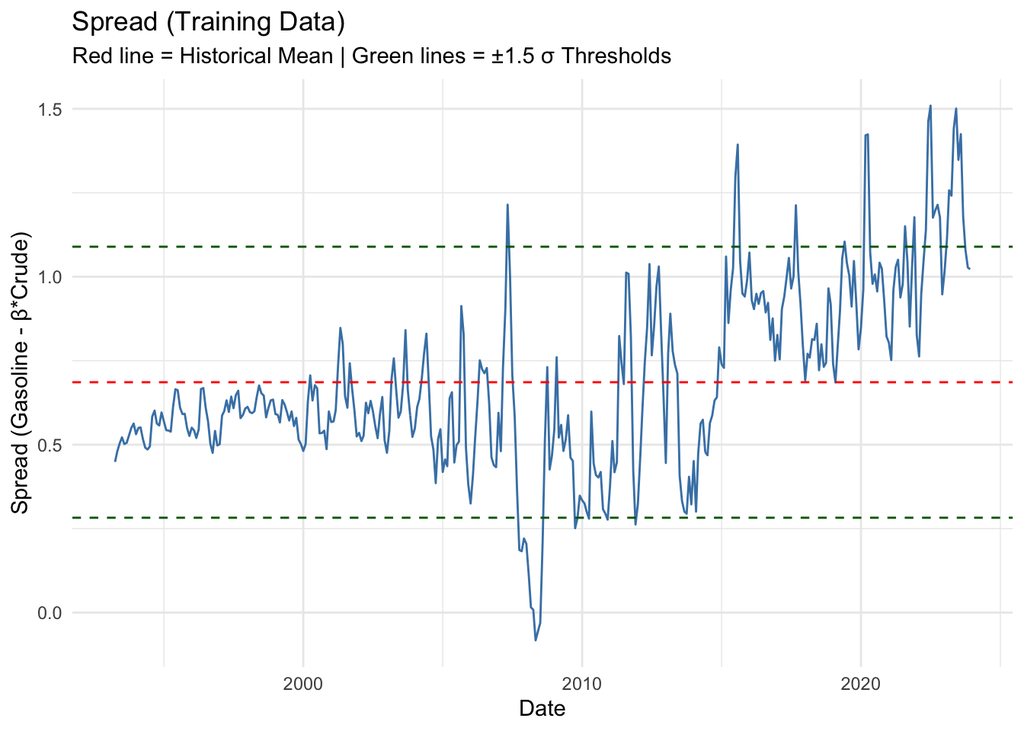

```r
historical_mean <- mean(train_spread, na.rm = TRUE)
historical_sd <- sd(train_spread, na.rm = TRUE)


# Convert time series to dataframe for plotting
train_spread_df <- data.frame(
  Date = as.Date(time(train_spread)),
  Spread = as.numeric(train_spread)
)

# Plot spread with historical mean and thresholds
ggplot(train_spread_df, aes(x = Date, y = Spread)) +
  geom_line(color = "steelblue") +
  geom_hline(yintercept = historical_mean, linetype = "dashed", color = "red") +
  geom_hline(yintercept = historical_mean + 1.5*historical_sd, linetype = "dashed", color = "darkgreen") +
  geom_hline(yintercept = historical_mean - 1.5*historical_sd, linetype = "dashed", color = "darkgreen") +
  labs(
    title = "Spread (Training Data)",
    subtitle = "Red line = Historical Mean | Green lines = ±1.5 σ Thresholds",
    x = "Date",
    y = "Spread (Gasoline - β*Crude)"
  ) +
  theme_minimal()
```

### Key Insights from graph

#### Interpretation

1. The blue line represents the spread (Gasoline - β * Crude) over time.
2. The red dashed line is the historical mean of the spread.
3. The green dashed lines are ±1.5 standard deviations from the mean, serving as thresholds.

#### ECM Application

1. Since gasoline and crude prices are cointegrated, any short-term deviation from equilibrium (spread) should eventually revert.
2. The ECM model quantifies this reversion force, allowing us to predict adjustments and trade accordingly.

### Conclusion

The model explains 53% of the variation in gasoline price changes, which is strong for economic data.

4. Implications for Arbitrage

Mean-Reverting Spread: The significant Spread_Lag1 term suggests the spread between gasoline and crude oil prices is predictable and mean-reverting.

5. Trading Strategy:

Buy the spread when it’s below its historical mean (expect it to rise).

Sell the spread when it’s above its historical mean (expect it to fall).

## Forecasting on testing data

```r
# Prepare test data with spread
test_spread <- test_gasoline - beta_train * test_crude
test_spread_lag1 <- stats::lag(test_spread, -1)  # Use stats::lag() on test_spread
test_spread_lag1 <- head(test_spread_lag1, -1)   # Ensure it aligns correctly

# Create test dataframe

valid_length <- min(length(diff(test_crude)), length(test_spread_lag1))

test_df <- data.frame(
  delta_crude = diff(test_crude)[1:valid_length],
  spread_lag1 = test_spread_lag1[1:valid_length]
) %>% na.omit()

# Predict delta_gasoline
test_df$pred_delta_gasoline <- predict(ecm_train, newdata = test_df)

# Convert delta to actual gasoline prices
test_df$pred_gasoline <- test_gasoline[1:(length(test_gasoline)-1)] + test_df$pred_delta_gasoline
```

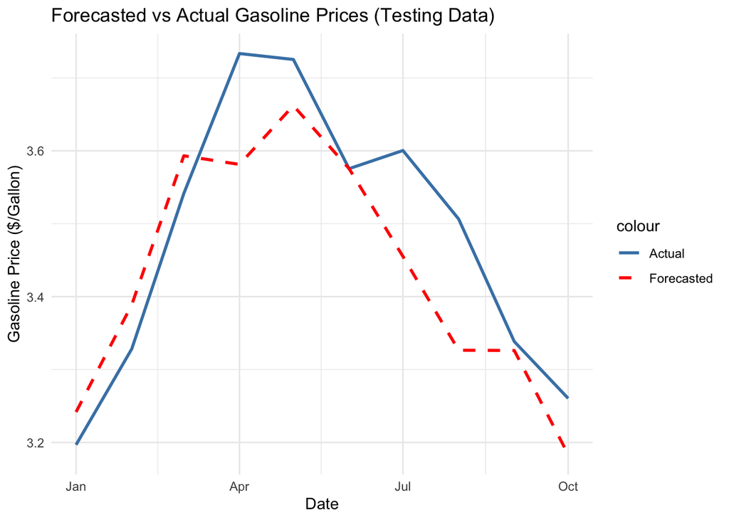

```r
# Create plotting dataframe
forecast_plot_df <- data.frame(
  Date = as.Date(time(test_gasoline))[1:(length(test_gasoline)-1)],
  Actual = as.numeric(test_gasoline[1:(length(test_gasoline)-1)]),
  Forecasted = test_df$pred_gasoline
)

# Plot forecasted vs actual
ggplot(forecast_plot_df, aes(x = Date)) +
  geom_line(aes(y = Actual, color = "Actual"), linewidth = 1) +
  geom_line(aes(y = Forecasted, color = "Forecasted"), linewidth = 1, linetype = "dashed") +
  labs(
    title = "Forecasted vs Actual Gasoline Prices (Testing Data)",
    x = "Date",
    y = "Gasoline Price ($/Gallon)"
  ) +
  scale_color_manual(values = c("Actual" = "steelblue", "Forecasted" = "red")) +
  theme_minimal()
```

### Key Insights from graph

#### Interpretation

1. Solid blue line: Actual gasoline prices.
2. Dashed red line: Forecasted gasoline prices using the ECM.

#### Key Insights

1. The ECM model captures the general price movement of gasoline well but deviates at certain points.
2. The predicted price leads to a mean-reverting expectation, indicating potential arbitrage opportunities.
3. If the forecasted price is significantly different from the actual price, a trading opportunity exists:

If forecasted price > actual price: Buy gasoline contracts.

If forecasted price < actual price: Sell gasoline contracts.

#### ECM Application

1. The ECM helps forecast gasoline prices based on past deviations from the crude price spread.
2. Short-term disequilibria between crude and gasoline prices are corrected using the model.

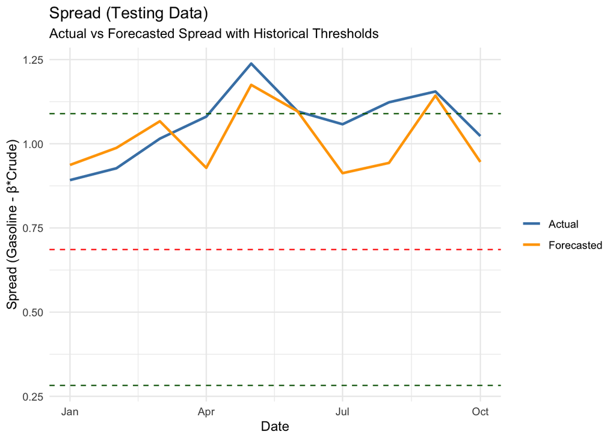

```r
# Prepare testing data with actual and forecasted spread
test_spread_actual <- test_gasoline - beta_train * test_crude
test_spread_forecast <- test_df$pred_gasoline - beta_train * test_crude[1:(length(test_crude)-1)]

# Combine into a dataframe
test_spread_plot_df <- data.frame(
  Date = as.Date(time(test_spread_actual))[1:(length(test_spread_actual)-1)],
  Actual = as.numeric(test_spread_actual)[1:(length(test_spread_actual)-1)],
  Forecasted = test_spread_forecast
) %>%
  pivot_longer(cols = c(Actual, Forecasted), names_to = "Type", values_to = "Spread")

# Plot testing data spread
test_spread_plot <- ggplot(test_spread_plot_df, aes(x = Date, y = Spread, color = Type)) +
  geom_line(linewidth = 1) +
  geom_hline(yintercept = historical_mean, linetype = "dashed", color = "red") +
  geom_hline(yintercept = historical_mean + 1.5 *historical_sd, linetype = "dashed", color = "darkgreen") +
  geom_hline(yintercept = historical_mean - 1.5 *historical_sd, linetype = "dashed", color = "darkgreen") +
  labs(
    title = "Spread (Testing Data)",
    subtitle = "Actual vs Forecasted Spread with Historical Thresholds",
    x = "Date",
    y = "Spread (Gasoline - β*Crude)",
    color = ""
  ) +
  scale_color_manual(values = c("Actual" = "steelblue", "Forecasted" = "orange")) +
  theme_minimal()

print(test_spread_plot)
```

### Metrics on forecasting

```r
# Extract actual and forecasted values from testing data
actual_gasoline <- test_gasoline[1:(length(test_gasoline)-1)]
forecasted_gasoline <- test_df$pred_gasoline

# Calculate residuals
residuals <- actual_gasoline - forecasted_gasoline

# Mean Absolute Error (MAE)
mae <- mean(abs(residuals), na.rm = TRUE)

# Root Mean Squared Error (RMSE)
rmse <- sqrt(mean(residuals^2, na.rm = TRUE))

# Mean Absolute Percentage Error (MAPE)
mape <- mean(abs(residuals / actual_gasoline), na.rm = TRUE) * 100

# R-squared
r_squared <- cor(actual_gasoline, forecasted_gasoline, use = "complete.obs")^2

# Directional Accuracy (DA)
direction_actual <- sign(diff(actual_gasoline))
direction_forecast <- sign(diff(forecasted_gasoline))
da <- mean(direction_actual == direction_forecast, na.rm = TRUE) * 100

# Create accuracy table
accuracy_table <- data.frame(
  Metric = c("MAE ($/Gallon)", "RMSE ($/Gallon)", "MAPE (%)", "R-squared", "Directional Accuracy (%)"),
  Value = c(
    round(mae, 4),
    round(rmse, 4),
    round(mape, 2),
    round(r_squared, 3),
    round(da, 2)
  )
)

# Display the accuracy table
print(accuracy_table)
```

```
##                     Metric   Value
## 1           MAE ($/Gallon)  0.0787
## 2          RMSE ($/Gallon)  0.0975
## 3                 MAPE (%)  2.2400
## 4                R-squared  0.7760
## 5 Directional Accuracy (%) 66.6700
```

### Key Insights

High Accuracy:

Trading Viability:

1. Directional accuracy of 66.67% means the model is profitable if transaction costs are low (e.g., 55-60% directional accuracy is often profitable).

## Trading strategy on testing data (2024)

```r
print(test_df)
```

```
##    delta_crude spread_lag1 pred_delta_gasoline pred_gasoline
## 1         3.10   0.8921116        4.496664e-02      3.241767
## 2         4.03   0.9272092        6.054198e-02      3.388792
## 3         4.07   1.0152010        5.167547e-02      3.593175
## 4        -5.33   1.0805996       -1.520826e-01      3.581317
## 5        -0.25   1.2381136       -6.323291e-02      3.662017
## 6         2.03   1.0961340        9.619974e-05      3.575596
## 7        -5.12   1.0579387       -1.451928e-01      3.455207
## 8        -6.44   1.1231756       -1.799866e-01      3.326513
## 9         1.75   1.1552400       -1.227602e-02      3.326124
## 10       -2.04   1.0229475       -7.693398e-02      3.183566
```

```r
print(test_gasoline)
```

```
##          Jan     Feb     Mar     Apr     May     Jun     Jul     Aug     Sep
## 2024 3.19680 3.32825 3.54150 3.73340 3.72525 3.57550 3.60040 3.50650 3.33840
##          Oct     Nov
## 2024 3.26050 3.17525
```

```r
# Compute Z-score for Predicted Spread (using ECM predictions)
test_df <- test_df %>%
  mutate(
    Z_Score = (test_spread_forecast - historical_mean) / historical_sd
  )

# Calculate profits
test_df <- test_df %>%
  mutate(
    Signal = case_when(
      Z_Score < -1.5 ~ "Buy",
      Z_Score > 1.5 ~ "Sell",
      TRUE ~ "Hold"
    )
  )

test_df <- test_df %>%
  mutate(
    Gasoline_Actual = test_gasoline[1:(length(test_gasoline)-1)],  # Match the length
    Gasoline_Next = lead(Gasoline_Actual)  # Get next-period gasoline price
  )

# Compute returns based on actual gasoline price movements
test_df <- test_df %>%
  mutate(
    Returns = case_when(
      Signal == "Buy" ~ (Gasoline_Next - Gasoline_Actual) * 1000,  # Profit if gasoline price rises
      Signal == "Sell" ~ (Gasoline_Actual - Gasoline_Next) * 1000,  # Profit if gasoline price falls
      TRUE ~ 0
    )
  )

# Compute total and cumulative profits
total_profit <- sum(test_df$Returns, na.rm = TRUE)
test_df <- test_df %>%
  mutate(Cumulative_Profit = cumsum(Returns))

# Print final profit result
cat("\nTotal Profit from ECM Spread Strategy: $", round(total_profit, 2), "\n")
```

```
##
## Total Profit from ECM Spread Strategy: $ 202.75
```

```r
# Display final dataframe
print(test_df)
```

```
##    delta_crude spread_lag1 pred_delta_gasoline pred_gasoline   Z_Score Signal
## 1         3.10   0.8921116        4.496664e-02      3.241767 0.9337193   Hold
## 2         4.03   0.9272092        6.054198e-02      3.388792 1.1220979   Hold
## 3         4.07   1.0152010        5.167547e-02      3.593175 1.4162494   Hold
## 4        -5.33   1.0805996       -1.520826e-01      3.581317 0.9018925   Hold
## 5        -0.25   1.2381136       -6.323291e-02      3.662017 1.8177594   Sell
## 6         2.03   1.0961340        9.619974e-05      3.575596 1.5253729   Sell
## 7        -5.12   1.0579387       -1.451928e-01      3.455207 0.8432626   Hold
## 8        -6.44   1.1231756       -1.799866e-01      3.326513 0.9564361   Hold
## 9         1.75   1.1552400       -1.227602e-02      3.326124 1.6991079   Sell
## 10       -2.04   1.0229475       -7.693398e-02      3.183566 0.9669366   Hold
##    Gasoline_Actual Gasoline_Next Returns Cumulative_Profit
## 1          3.19680       3.32825    0.00              0.00
## 2          3.32825       3.54150    0.00              0.00
## 3          3.54150       3.73340    0.00              0.00
## 4          3.73340       3.72525    0.00              0.00
## 5          3.72525       3.57550  149.75            149.75
## 6          3.57550       3.60040  -24.90            124.85
## 7          3.60040       3.50650    0.00            124.85
## 8          3.50650       3.33840    0.00            124.85
## 9          3.33840       3.26050   77.90            202.75
## 10         3.26050            NA    0.00            202.75
```

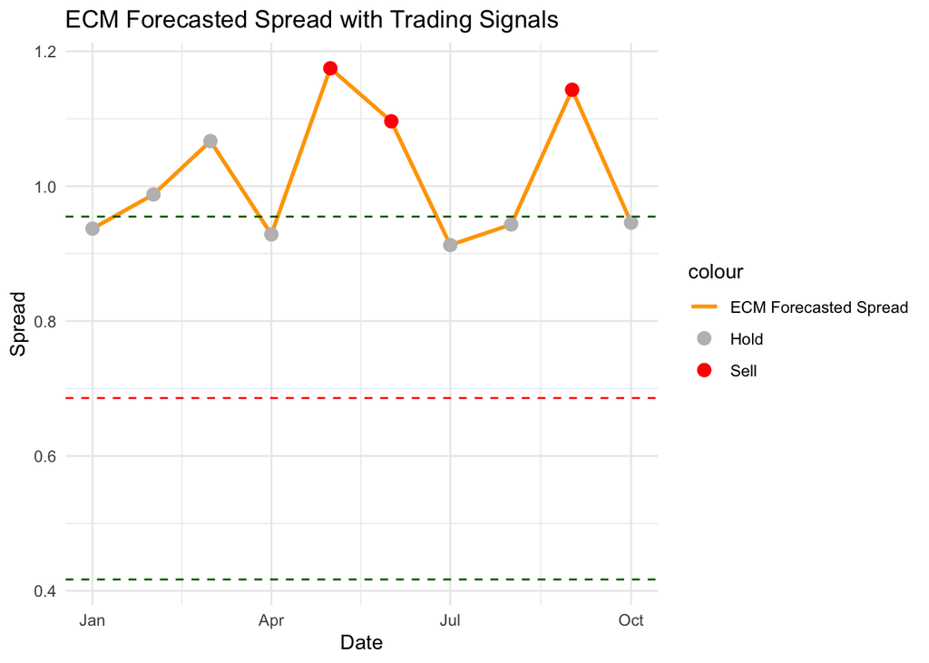

```r
# Create a dataframe for plotting
test_df <- test_df %>%
  mutate(
    Date = as.Date(time(test_spread))[1:(length(test_spread)-1)],
    Spread_Forecast = test_spread_forecast  # Rename to ensure it's recognized as a column
  )

# Create a dataframe for plotting
plot_df <- dplyr::select(test_df, Date, Spread_Forecast, Gasoline_Actual, Signal)


# Plot Spread with Trading Signals
spread_plot <- ggplot(plot_df, aes(x = Date)) +
  geom_line(aes(y = test_spread_forecast, color = "ECM Forecasted Spread"), linewidth = 1) +  # ECM Spread Line
  geom_point(aes(y = test_spread_forecast, color = Signal), size = 3) +  # Signal points on spread
  geom_hline(yintercept = historical_mean, linetype = "dashed", color = "red") +
  geom_hline(yintercept = historical_mean + 1 * historical_sd, linetype = "dashed", color = "darkgreen") +
  geom_hline(yintercept = historical_mean - 1 * historical_sd, linetype = "dashed", color = "darkgreen") +
  labs(
    title = "ECM Forecasted Spread with Trading Signals",
    x = "Date",
    y = "Spread"
  ) +
  scale_color_manual(values = c("Buy" = "green", "Sell" = "red", "Hold" = "gray", "ECM Forecasted Spread" = "orange")) +
  theme_minimal()

# Plot Actual Gasoline Price with Trading Signals
gasoline_plot <- ggplot(plot_df, aes(x = Date)) +
  geom_line(aes(y = Gasoline_Actual, color = "Actual Gasoline Price"), linewidth = 1) +  # Actual Gasoline Price Line
  geom_point(aes(y = Gasoline_Actual, color = Signal), size = 3) +  # Signal points on gasoline price
  labs(
    title = "Actual Gasoline Price with Trading Signals",
    x = "Date",
    y = "Gasoline Price"
  ) +
  scale_color_manual(values = c("Buy" = "green", "Sell" = "red", "Hold" = "gray", "Actual Gasoline Price" = "steelblue")) +
  theme_minimal()

# Print both plots
print(spread_plot)
```

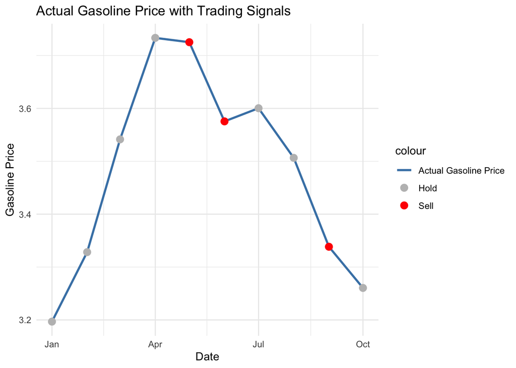

```r
print(gasoline_plot)
```

### Interpretation

1.Orange line: Forecasted Spread between gasoline and crude.

2.Gray dots: Hold signals (spread is within normal range).

3. Red dots: Sell signals (spread is excessively high).
4. Blue line: Actual Gasoline price data when signals are triggered

### ECM Application

1. The ECM model identifies deviations from equilibrium and determines when to trade based on spread levels.
2. The model captures the short-term correction behavior in gasoline prices relative to crude.

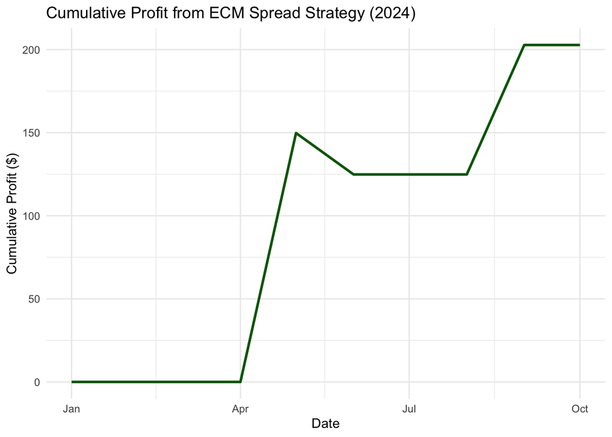

```r
# Ensure Date and Cumulative Profit columns are correctly defined
test_df <- test_df %>%
  mutate(
    Date = as.Date(time(test_spread))[1:(length(test_spread)-1)],  # Align dates properly
    Cumulative_Profit = cumsum(replace_na(Returns, 0))  # Compute cumulative profit over time
  )

# Plot cumulative profit over time
cumulative_profit_plot <- ggplot(test_df, aes(x = Date, y = Cumulative_Profit)) +
  geom_line(color = "darkgreen", linewidth = 1) +  # Profit trend line
  labs(
    title = "Cumulative Profit from ECM Spread Strategy (2024)",
    x = "Date",
    y = "Cumulative Profit ($)"
  ) +
  theme_minimal()

# Print the plot
print(cumulative_profit_plot)
```

### Key Insights from Graph

#### Interpretation

1. The green line represents cumulative trading profits over time.
2. The plot tracks profit accumulation as ECM-based trading signals are executed.

#### Key Insights

1. The strategy starts with no immediate profits, indicating a cautious entry into trades.
2. A sharp increase in cumulative profit occurs around April, suggesting that key trading signals were correctly executed.
3. The strategy remains stable with minimal drawdowns, indicating controlled risk management.
4. By late 2024, cumulative profit increases significantly, demonstrating successful mean-reversion trades and well-timed execution.

#### ECM Application

# Model 2: VAR

```r
# ADF test for Crude Oil Prices
adf_crude <- adf.test(na.omit(crude_ts))
print(adf_crude)
```

```
##
##  Augmented Dickey-Fuller Test
##
## data:  na.omit(crude_ts)
## Dickey-Fuller = -2.5724, Lag order = 7, p-value = 0.3354
## alternative hypothesis: stationary
```

```r
# ADF test for Gasoline Prices
adf_gasoline <- adf.test(na.omit(gasoline_ts))
print(adf_gasoline)
```

```
##
##  Augmented Dickey-Fuller Test
##
## data:  na.omit(gasoline_ts)
## Dickey-Fuller = -2.4815, Lag order = 7, p-value = 0.3738
## alternative hypothesis: stationary
```

Differencing required because p-val > 0.05

```r
# first order differencing
train_crude_diff <- diff(train_crude, differences=1)
train_gasoline_diff <- diff(train_gasoline, differences=1)

test_crude_diff <- diff(test_crude, differences=1)
test_gasoline_diff <- diff(test_gasoline, differences=1)
```

```r
# recheck stationarity
adf_crude_diff <- adf.test(train_crude_diff)
adf_gasoline_diff <- adf.test(train_gasoline_diff)
print(adf_crude_diff)
```

```
##
##  Augmented Dickey-Fuller Test
##
## data:  train_crude_diff
## Dickey-Fuller = -7.2988, Lag order = 7, p-value = 0.01
## alternative hypothesis: stationary
```

```r
print(adf_gasoline_diff)
```

```
##
##  Augmented Dickey-Fuller Test
##
## data:  train_gasoline_diff
## Dickey-Fuller = -9.1872, Lag order = 7, p-value = 0.01
## alternative hypothesis: stationary
```

p-val < 0.05, therefore stationary and can continue

```r
# determine optimal lag order using AIC/BIC

lag_selection <- VARselect(cbind(train_crude_diff, train_gasoline_diff),
                           lag.max = 10, type = "const")

print(lag_selection$selection)
```

```
## AIC(n)  HQ(n)  SC(n) FPE(n)
##     10      2      1     10
```

AIC = 10 and BIC = 1. We will use AIC for the optimal lags.

```r
optimal_lag <- 10

var_model <- VAR(cbind(train_crude_diff, train_gasoline_diff),
                 p = optimal_lag, type = "const")

summary(var_model)
```

```
##
## VAR Estimation Results:
## =========================
## Endogenous variables: train_crude_diff, train_gasoline_diff
## Deterministic variables: const
## Sample size: 358
## Log Likelihood: -694.351
## Roots of the characteristic polynomial:
## 0.939 0.939 0.8775 0.8775 0.8733 0.8733 0.8334 0.8334 0.7927 0.7927 0.7922 0.7922 0.7699 0.7699 0.7647 0.7647 0.6928 0.6928 0.5542 0.2686
## Call:
## VAR(y = cbind(train_crude_diff, train_gasoline_diff), p = optimal_lag,
##     type = "const")
##
##
## Estimation results for equation train_crude_diff:
## =================================================
## train_crude_diff = train_crude_diff.l1 + train_gasoline_diff.l1 + train_crude_diff.l2 + train_gasoline_diff.l2 + train_crude_diff.l3 + train_gasoline_diff.l3 + train_crude_diff.l4 + train_gasoline_diff.l4 + train_crude_diff.l5 + train_gasoline_diff.l5 + train_crude_diff.l6 + train_gasoline_diff.l…
##
##                          Estimate Std. Error t value Pr(>|t|)
## train_crude_diff.l1      0.468587   0.073233   6.399 5.25e-10 ***
## train_gasoline_diff.l1  -8.106253   2.925265  -2.771  0.00590 **
## train_crude_diff.l2      0.104976   0.080151   1.310  0.19118
## train_gasoline_diff.l2  -0.070647   2.941287  -0.024  0.98085
## train_crude_diff.l3     -0.064806   0.081222  -0.798  0.42550
## train_gasoline_diff.l3  -0.778680   3.064495  -0.254  0.79958
## train_crude_diff.l4      0.008372   0.082530   0.101  0.91926
## train_gasoline_diff.l4  -1.399803   3.042283  -0.460  0.64573
## train_crude_diff.l5      0.092098   0.081310   1.133  0.25815
## train_gasoline_diff.l5  -3.100726   3.034099  -1.022  0.30753
## train_crude_diff.l6     -0.105242   0.081836  -1.286  0.19932
## train_gasoline_diff.l6  -1.945756   3.039368  -0.640  0.52249
## train_crude_diff.l7      0.071496   0.081525   0.877  0.38112
## train_gasoline_diff.l7  -3.960491   3.087907  -1.283  0.20052
## train_crude_diff.l8      0.115635   0.082137   1.408  0.16010
## train_gasoline_diff.l8  -2.696299   3.064862  -0.880  0.37962
## train_crude_diff.l9      0.107318   0.081184   1.322  0.18709
## train_gasoline_diff.l9  -7.723748   2.972368  -2.599  0.00977 **
## train_crude_diff.l10    -0.039534   0.082311  -0.480  0.63132
## train_gasoline_diff.l10  4.676195   2.669705   1.752  0.08076 .
## const                    0.208590   0.260858   0.800  0.42449
```

[output cut: 39 more lines]

```
## Residual standard error: 0.1202 on 337 degrees of freedom
## Multiple R-Squared: 0.4504,  Adjusted R-squared: 0.4178
## F-statistic: 13.81 on 20 and 337 DF,  p-value: < 2.2e-16
##
##
##
## Covariance matrix of residuals:
##                     train_crude_diff train_gasoline_diff
## train_crude_diff             23.4307             0.38876
## train_gasoline_diff           0.3888             0.01444
##
## Correlation matrix of residuals:
##                     train_crude_diff train_gasoline_diff
## train_crude_diff              1.0000              0.6684
## train_gasoline_diff           0.6684              1.0000
```

```r
serial_test <- serial.test(var_model, type = "BG")
print(serial_test)
```

```
##
##  Breusch-Godfrey LM test
##
## data:  Residuals of VAR object var_model
## Chi-squared = 25.203, df = 20, p-value = 0.1938
```

```
## $serial
##
##  Breusch-Godfrey LM test
##
## data:  Residuals of VAR object var_model
## Chi-squared = 25.203, df = 20, p-value = 0.1938
```

The Breusch-Godfrey test is better for small samples, and we get p values > 0.05 meaning there is no significant serial correlation in the residuals.

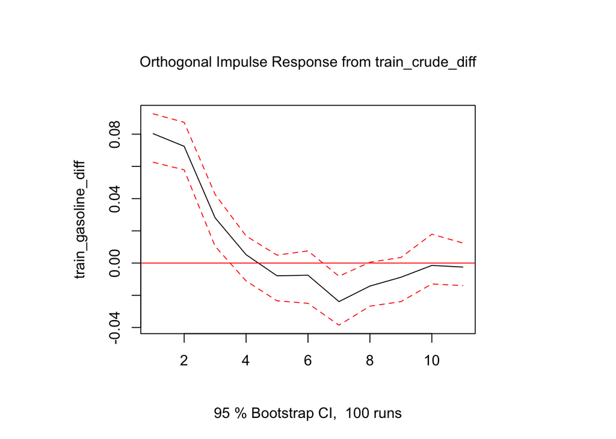

```r
irf_result <- irf(var_model, impulse = "train_crude_diff", response = "train_gasoline_diff", n.ahead = 10)
plot(irf_result)
```

### Inference

Black Line = Mean response of gasoline price changes to a crude oil price shock. Red Dashed Lines = 95% Bootstrap Confidence Interval (CI) (from 100 simulations).

### Key Takeaway

We are visualizing the impack on gasoline prices with a shock on the crude oil prices. - A positive shock in crude oil price changes causes gasoline price changes to rise sharply (peak at ~0.08 within the first 2 periods). - Gasoline prices react immediately to crude oil price changes (due to refining costs and market expectations). - This aligns with economic intuition: when crude oil prices rise, gasoline prices adjust but do not experience indefinite price changes. - The confidence bands (red dashed lines) are above 0 initially, confirming that the impact is statistically significant for the first 3-4 periods.

```r
# Forecasting future values
var_forecast <- predict(var_model, n.ahead = length(test_crude_diff))

forecast_vs_actual <- data.frame(
  Date = seq(from = as.Date("2024-02-01"), by = "1 month", length.out = length(test_crude_diff)),  # Adjust dates dynamically
  Actual_Crude = test_crude_diff,
  Forecast_Crude = var_forecast$fcst$train_crude_diff[,1],  # First column is mean forecast
  Actual_Gasoline = test_gasoline_diff,
  Forecast_Gasoline = var_forecast$fcst$train_gasoline_diff[,1]
)
print(forecast_vs_actual)
```

```
##          Date Actual_Crude Forecast_Crude Actual_Gasoline Forecast_Gasoline
## 1  2024-02-01         3.10     -3.6189082         0.13145     -0.0631893893
## 2  2024-03-01         4.03     -0.6718200         0.21325      0.0008156338
## 3  2024-04-01         4.07     -0.3089523         0.19190      0.0394289711
## 4  2024-05-01        -5.33      2.2523955        -0.00815      0.1396269183
## 5  2024-06-01        -0.25      1.7673392        -0.14975      0.1129635558
## 6  2024-07-01         2.03      3.6820191         0.02490      0.1585162268
## 7  2024-08-01        -5.12      2.1174775        -0.09390      0.0923429331
## 8  2024-09-01        -6.44      0.7912546        -0.16810     -0.0098782571
## 9  2024-10-01         1.75     -0.4740885        -0.07790     -0.0734729947
## 10 2024-11-01        -2.04     -1.2276148        -0.08525     -0.0958027328
```

```r
# Forecasting future values
var_forecast <- predict(var_model, n.ahead = length(test_crude_diff))

# Convert differenced forecasts back to actual prices
Forecast_Crude <- test_crude[length(test_crude)] + cumsum(var_forecast$fcst$train_crude_diff[,1])
Forecast_Gasoline <- test_gasoline[length(test_gasoline)] + cumsum(var_forecast$fcst$train_gasoline_diff[,1])

# Ensure all columns have the same length
n <- min(length(test_crude_diff), length(Forecast_Crude), length(Forecast_Gasoline), length(test_gasoline))

# Trim all variables to the same length
test_crude <- test_crude[1:n]
Forecast_Crude <- Forecast_Crude[1:n]
test_gasoline <- test_gasoline[1:n]
Forecast_Gasoline <- Forecast_Gasoline[1:n]

# Create forecast_vs_actual dataframe with actual prices
forecast_vs_actual <- data.frame(
  Date = seq(from = as.Date("2024-02-01"), by = "1 month", length.out = n),
  Actual_Crude = test_crude,
  Forecast_Crude = Forecast_Crude,
  Actual_Gasoline = test_gasoline,
  Forecast_Gasoline = Forecast_Gasoline
)

print(forecast_vs_actual)
```

```
##          Date Actual_Crude Forecast_Crude Actual_Gasoline Forecast_Gasoline
## 1  2024-02-01        74.15       66.33109         3.19680          3.112061
## 2  2024-03-01        77.25       65.65927         3.32825          3.112876
## 3  2024-04-01        81.28       65.35032         3.54150          3.152305
## 4  2024-05-01        85.35       67.60271         3.73340          3.291932
## 5  2024-06-01        80.02       69.37005         3.72525          3.404896
## 6  2024-07-01        79.77       73.05207         3.57550          3.563412
## 7  2024-08-01        81.80       75.16955         3.60040          3.655755
## 8  2024-09-01        76.68       75.96081         3.50650          3.645877
## 9  2024-10-01        70.24       75.48672         3.33840          3.572404
## 10 2024-11-01        71.99       74.25910         3.26050          3.476601
```

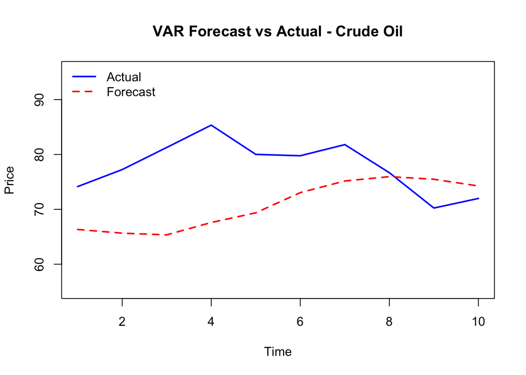

```r
Forecast_Gasoline <- forecast_vs_actual$Forecast_Gasoline
Forecast_Crude <- forecast_vs_actual$Forecast_Crude

# Find min and max values to set appropriate bounds
y_min <- min(c(test_crude, Forecast_Crude)) - 10  # Extend lower bound slightly
y_max <- max(c(test_crude, Forecast_Crude)) + 10  # Extend upper bound slightly

# Crude Oil Forecast Plot (Actual vs Forecasted Prices)
plot(test_crude, type="l", col="blue", lwd=2, ylab="Price", xlab="Time",
     main="VAR Forecast vs Actual - Crude Oil",
     ylim=c(y_min, y_max))  # Adjust y-axis bounds

lines(Forecast_Crude, col="red", lwd=2, lty=2)  # Add forecast line
legend("topleft", legend=c("Actual", "Forecast"),
       col=c("blue", "red"), lwd=2, lty=c(1,2), bty="n")
```

```r
test_crude <- window(crude_ts, start = c(2024, 1), end = c(2024, 11))
test_gasoline <- window(gasoline_ts, start = c(2024, 1), end = c(2024, 11))
# Extract the slope coefficient for calculating spread
beta_train <- 0.031081434515637156

# Actual spread in test set
test_spread_actual <- test_gasoline - beta_train * test_crude

# Forecasted spread using ARIMAX predictions
test_spread_forecast <- Forecast_Gasoline - beta_train * test_crude
```

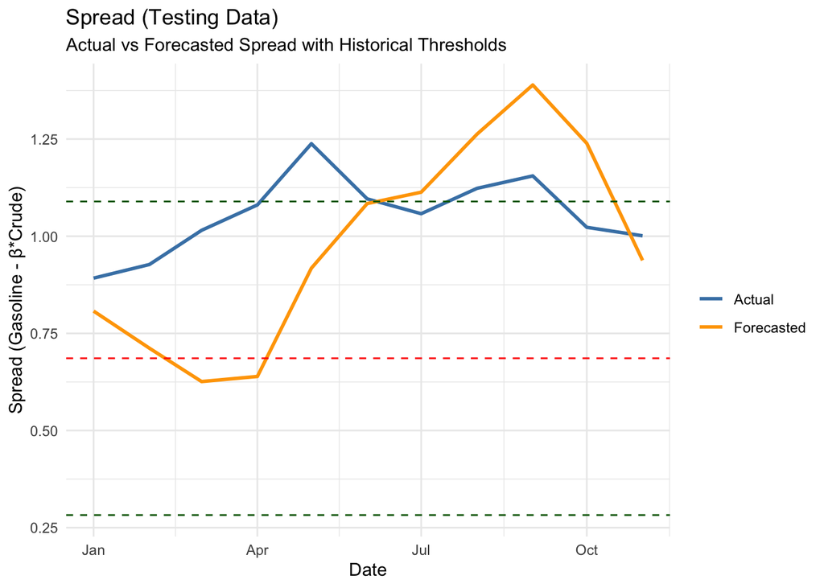

```r
# Compute historical mean and standard deviation from the training spread
historical_spread <- train_gasoline - beta_train * train_crude
historical_mean <- mean(historical_spread, na.rm = TRUE)
historical_sd <- sd(historical_spread, na.rm = TRUE)

# Combine into a dataframe
test_spread_plot_df <- data.frame(
  Date = as.Date(time(test_spread_actual))[1:(length(test_spread_actual))],
  Actual = as.numeric(test_spread_actual)[1:(length(test_spread_actual))],
  Forecasted = test_spread_forecast
) %>%
  pivot_longer(cols = c(Actual, Forecasted), names_to = "Type", values_to = "Spread")

# Plot testing data spread
test_spread_plot <- ggplot(test_spread_plot_df, aes(x = Date, y = Spread, color = Type)) +
  geom_line(linewidth = 1) +
  geom_hline(yintercept = historical_mean, linetype = "dashed", color = "red") +
  geom_hline(yintercept = historical_mean + 1.5*historical_sd, linetype = "dashed", color = "darkgreen") +
  geom_hline(yintercept = historical_mean - 1.5*historical_sd, linetype = "dashed", color = "darkgreen") +
  labs(
    title = "Spread (Testing Data)",
    subtitle = "Actual vs Forecasted Spread with Historical Thresholds",
    x = "Date",
    y = "Spread (Gasoline - β*Crude)",
    color = ""
  ) +
  scale_color_manual(values = c("Actual" = "steelblue", "Forecasted" = "orange")) +
  theme_minimal()

print(test_spread_plot)
```

```r
test_dates <- time(test_crude)
test_dates <- test_dates[1:length(test_spread_forecast)]

# Ensure test_spread_forecast aligns with test dates
test_df <- data.frame(
  Date = test_dates,  # Ensure this is correctly assigned
  Spread_Forecast = test_spread_forecast
)

# Compute Z-score for spread forecast
test_df <- test_df %>%
  mutate(
    Z_Score = (Spread_Forecast - historical_mean) / historical_sd
  )

# Generate Buy/Sell/Hold signals based on Z-score
test_df <- test_df %>%
  mutate(
    Signal = case_when(
      Z_Score < -1.5 ~ "Buy",
      Z_Score > 1.5 ~ "Sell",
      TRUE ~ "Hold"
    )
  )

# Align actual gasoline prices properly
test_df <- test_df %>%
  mutate(
    Gasoline_Actual = test_gasoline[1:(length(test_gasoline))],  # Match the length
    Gasoline_Next = lead(Gasoline_Actual)  # Get next-period gasoline price
  )

# Compute trading returns based on signals
test_df <- test_df %>%
  mutate(
    Returns = case_when(
      Signal == "Buy" ~ (Gasoline_Next - Gasoline_Actual) * 1000,  # Profit if price rises
      Signal == "Sell" ~ (Gasoline_Actual - Gasoline_Next) * 1000,  # Profit if price falls
      TRUE ~ 0
    )
  )

# Compute cumulative profit
test_df <- test_df %>%
  mutate(Cumulative_Profit = cumsum(coalesce(Returns, 0)))

# Compute total profit
total_profit <- sum(test_df$Returns, na.rm = TRUE)
cat("\nTotal Profit from VAR Spread Strategy: $", round(total_profit, 2), "\n")
```

```
##
## Total Profit from VAR Spread Strategy: $ 425.15
```

```r
test_df
```

```
##        Date Spread_Forecast     Z_Score Signal Gasoline_Actual Gasoline_Next
## 1  2024.000       0.8073722  0.45153196   Hold         3.19680       3.32825
## 2  2024.083       0.7118354  0.09637001   Hold         3.32825       3.54150
## 3  2024.167       0.6260062 -0.22270353   Hold         3.54150       3.73340
## 4  2024.250       0.6391317 -0.17390903   Hold         3.73340       3.72525
## 5  2024.333       0.9177593  0.86190029   Hold         3.72525       3.57550
## 6  2024.417       1.0840459  1.48007736   Hold         3.57550       3.60040
## 7  2024.500       1.1132935  1.58880656   Sell         3.60040       3.50650
## 8  2024.583       1.2625522  2.14368174   Sell         3.50650       3.33840
## 9  2024.667       1.3892436  2.61466227   Sell         3.33840       3.26050
## 10 2024.750       1.2390484  2.05630542   Sell         3.26050       3.17525
## 11 2024.833       0.9379143  0.93682719   Hold         3.17525            NA
##    Returns Cumulative_Profit
## 1     0.00              0.00
## 2     0.00              0.00
## 3     0.00              0.00
## 4     0.00              0.00
## 5     0.00              0.00
## 6     0.00              0.00
## 7    93.90             93.90
## 8   168.10            262.00
## 9    77.90            339.90
## 10   85.25            425.15
## 11    0.00            425.15
```

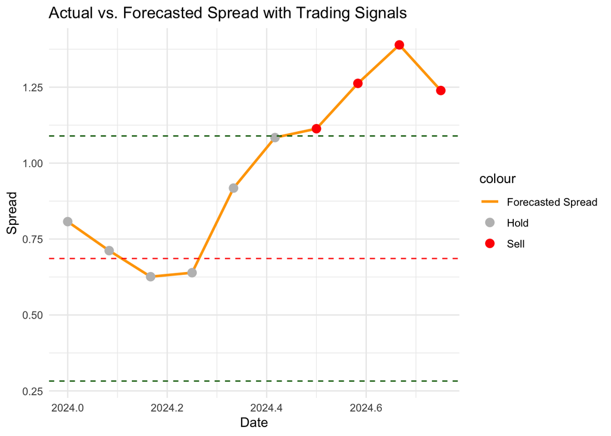

```r
Actual_Gasoline <- forecast_vs_actual$Actual_Gasoline
Actual_Crude <- forecast_vs_actual$Actual_Crude
test_df <- test_df[-nrow(test_df), ]
plot_df <- test_df %>%
  mutate(
    Spread_Actual = Actual_Gasoline - Actual_Crude
  )

spread_plot <- ggplot(plot_df, aes(x = Date)) +

  geom_line(aes(y = Spread_Forecast, color = "Forecasted Spread"), size = 1) +

  geom_point(aes(y = Spread_Forecast, color = Signal), size = 3) +

  geom_hline(yintercept = historical_mean, linetype = "dashed", color = "red") +
  geom_hline(yintercept = historical_mean + 1.5*historical_sd, linetype = "dashed", color = "darkgreen") +
  geom_hline(yintercept = historical_mean - 1.5*historical_sd, linetype = "dashed", color = "darkgreen") +

  labs(
    title = "Actual vs. Forecasted Spread with Trading Signals",
    x = "Date",
    y = "Spread"
  ) +

  scale_color_manual(values = c(
    "Buy"               = "green",
    "Sell"              = "red",
    "Hold"              = "gray",
    "Forecasted Spread" = "orange"  # Remove "Actual Spread"
  )) +

  theme_minimal()
# Keep gasoline plot unchanged
gasoline_plot <- ggplot(plot_df, aes(x = Date)) +
  geom_line(aes(y = Actual_Gasoline, color = "Actual Gasoline Price"), size = 1) +
  geom_point(aes(y = Actual_Gasoline, color = Signal), size = 3) +
  labs(
    title = "Actual Gasoline Price with Trading Signals",
    x = "Date",
    y = "Gasoline Price"
  ) +
  scale_color_manual(values = c(
    "Buy"                   = "green",
    "Sell"                  = "red",
    "Hold"                  = "gray",
    "Actual Gasoline Price" = "steelblue"
  )) +
  theme_minimal()

print(spread_plot)
```

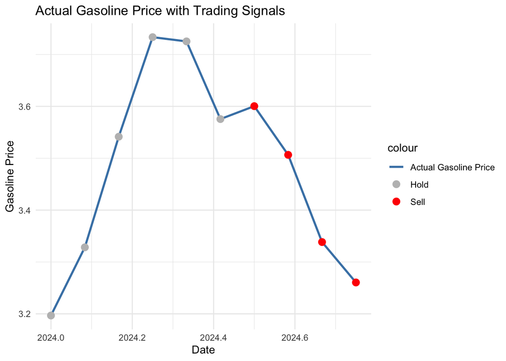

```r
print(gasoline_plot)
```

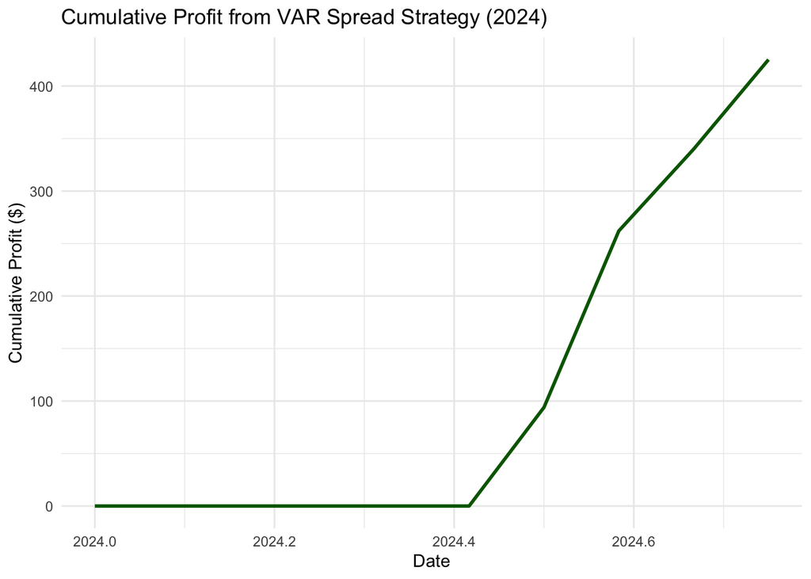

```r
# Ensure Date and Cumulative Profit columns are correctly defined
test_df <- test_df %>%
  mutate(
    Cumulative_Profit = cumsum(replace_na(Returns, 0))  # Compute cumulative profit over time
  )

# Plot cumulative profit over time
cumulative_profit_plot <- ggplot(test_df, aes(x = Date, y = Cumulative_Profit)) +
  geom_line(color = "darkgreen", linewidth = 1) +  # Profit trend line
  labs(
    title = "Cumulative Profit from VAR Spread Strategy (2024)",
    x = "Date",
    y = "Cumulative Profit ($)"
  ) +
  theme_minimal()

# Print the plot
print(cumulative_profit_plot)
```

### Key Takeaway

The Cumulative profit from the VAR spread strategy shows that we make $425 in profit. Though we have an upward trajectory in our profit curve, VAR might not be as well suited for volatile economic data like Gasoline and Crude Oil, and different models like ECM are better suited.

```r
residuals_gasoline <- test_gasoline - Forecast_Gasoline
residuals_crude <- test_crude - Forecast_Crude
```

```r
# Mean Absolute Error (MAE)
mae_gasoline <- mean(abs(residuals_gasoline), na.rm = TRUE)
mae_crude <- mean(abs(residuals_crude), na.rm = TRUE)

# Root Mean Squared Error (RMSE)
rmse_gasoline <- sqrt(mean(residuals_gasoline^2, na.rm = TRUE))
rmse_crude <- sqrt(mean(residuals_crude^2, na.rm = TRUE))

# Mean Absolute Percentage Error (MAPE)
mape_gasoline <- mean(abs(residuals_gasoline / test_gasoline), na.rm = TRUE) * 100
mape_crude <- mean(abs(residuals_crude / test_crude), na.rm = TRUE) * 100

print(rmse_gasoline)
```

```
## [1] 0.2394399
```

```r
print(rmse_crude)
```

```
## [1] 9.596432
```

```r
print(mape_gasoline)
```

```
## [1] 5.637587
```

```r
print(mape_crude)
```

```
## [1] 10.22823
```

### Key Takeaway

# Model 3: ARIMAX

ARIMA model requires a stationary time series similar to VAR model so we will use the differenced time series for crude oil and gasoline prices. However, before we move forward with the modelling, it would be helpful to understand the presence of any AR or MA terms in the time series.

```r
# Recheck stationarity to make sure
adf.test(train_crude_diff)
```

```
##
##  Augmented Dickey-Fuller Test
##
## data:  train_crude_diff
## Dickey-Fuller = -7.2988, Lag order = 7, p-value = 0.01
## alternative hypothesis: stationary
```

```r
adf.test(train_gasoline_diff)
```

```
##
##  Augmented Dickey-Fuller Test
##
## data:  train_gasoline_diff
## Dickey-Fuller = -9.1872, Lag order = 7, p-value = 0.01
## alternative hypothesis: stationary
```

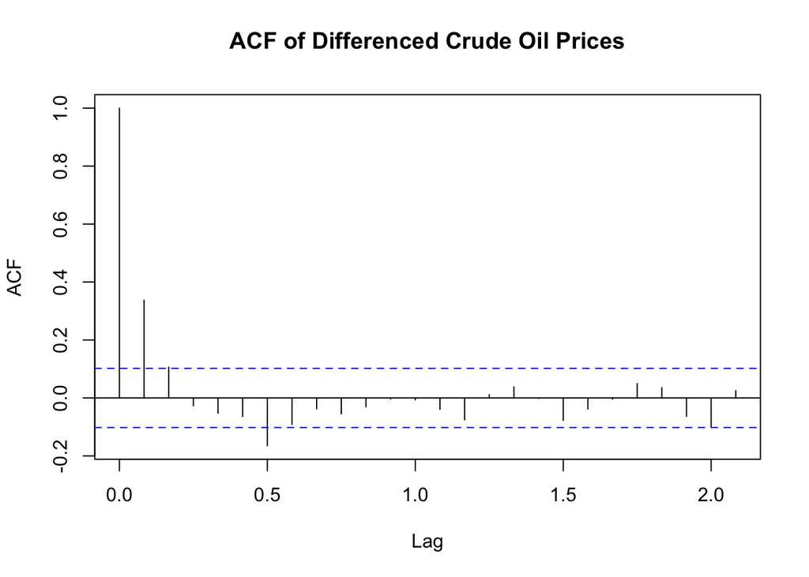

```r
# Replot ACF and PACF after differencing to understand presence of AR and MA components
acf(train_crude_diff, main="ACF of Differenced Crude Oil Prices")
```

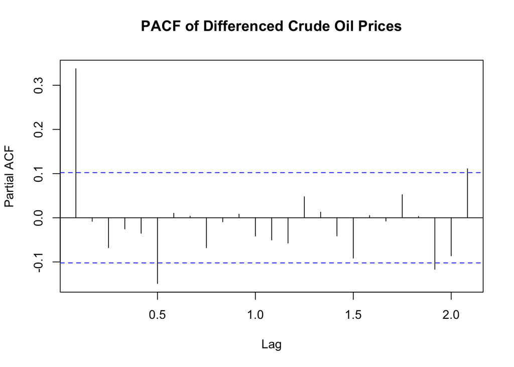

```r
pacf(train_crude_diff, main="PACF of Differenced Crude Oil Prices")
```

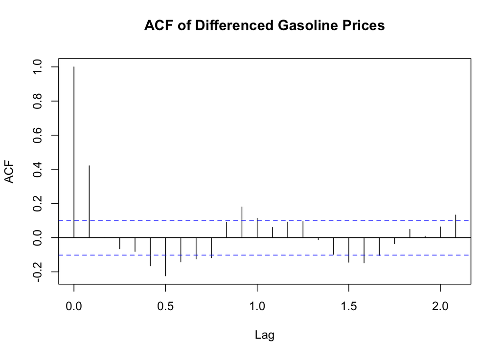

```r
acf(train_gasoline_diff, main="ACF of Differenced Gasoline Prices")
```

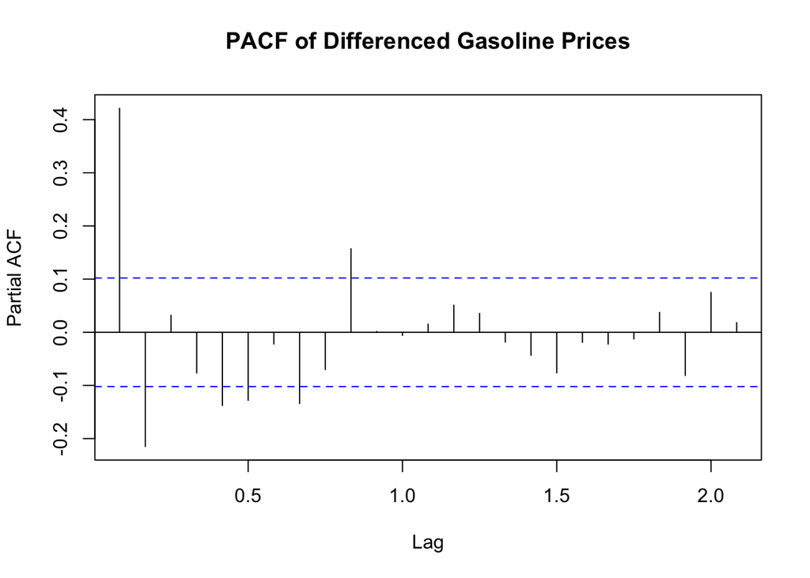

```r
pacf(train_gasoline_diff, main="PACF of Differenced Gasoline Prices")
```

### Insights

Stationarity: * ADF test: Both crude oil prices and gasoline prices are stationary after differencing (p-values < 0.05). * ACF plot: ACF declines sharply for crude oil and gasoline prices, confirming stationarity.

Crude Oil Prices (Differenced): * ACF pattern: Shows significant autocorrelation at lag 1 that cuts off after that, suggesting an MA(1) component. * PACF pattern: Shows a significant spike at lag 1 with a sharp decline afterward, suggesting an AR(1) component. * The combined pattern suggests an ARMA(1,1) structure could be appropriate.

```r
# Fit auto ARIMA for gasoline and crude oil prices
model_gasoline <- auto.arima(train_gasoline_diff, stepwise = TRUE, trace = TRUE)
```

```
##
##  Fitting models using approximations to speed things up...
##
##  ARIMA(2,0,2)(1,0,1)[12] with non-zero mean : Inf
##  ARIMA(0,0,0)            with non-zero mean : -322.953
##  ARIMA(1,0,0)(1,0,0)[12] with non-zero mean : -378.8244
##  ARIMA(0,0,1)(0,0,1)[12] with non-zero mean : -408.4796
##  ARIMA(0,0,0)            with zero mean     : -324.4395
##  ARIMA(0,0,1)            with non-zero mean : -409.1052
##  ARIMA(0,0,1)(1,0,0)[12] with non-zero mean : -396.7566
##  ARIMA(0,0,1)(1,0,1)[12] with non-zero mean : Inf
##  ARIMA(1,0,1)            with non-zero mean : -406.963
##  ARIMA(0,0,2)            with non-zero mean : -408.121
##  ARIMA(1,0,0)            with non-zero mean : -392.1719
##  ARIMA(1,0,2)            with non-zero mean : -405.3354
##  ARIMA(0,0,1)            with zero mean     : -410.8402
##  ARIMA(0,0,1)(1,0,0)[12] with zero mean     : -398.5182
##  ARIMA(0,0,1)(0,0,1)[12] with zero mean     : -410.2576
##  ARIMA(0,0,1)(1,0,1)[12] with zero mean     : Inf
##  ARIMA(1,0,1)            with zero mean     : -408.7508
##  ARIMA(0,0,2)            with zero mean     : -409.9004
##  ARIMA(1,0,0)            with zero mean     : -394.0212
##  ARIMA(1,0,2)            with zero mean     : -407.1253
##
##  Now re-fitting the best model(s) without approximations...
##
##  ARIMA(0,0,1)            with zero mean     : -410.5645
##
##  Best model: ARIMA(0,0,1)            with zero mean
```

```r
model_crude <- auto.arima(train_crude_diff, stepwise = TRUE, trace = TRUE)
```

```
##
##  Fitting models using approximations to speed things up...
##
##  ARIMA(2,0,2)(1,0,1)[12] with non-zero mean : 2235.985
##  ARIMA(0,0,0)            with non-zero mean : 2256.543
##  ARIMA(1,0,0)(1,0,0)[12] with non-zero mean : 2228.64
##  ARIMA(0,0,1)(0,0,1)[12] with non-zero mean : 2221.114
##  ARIMA(0,0,0)            with zero mean     : 2254.793
##  ARIMA(0,0,1)            with non-zero mean : 2219.075
##  ARIMA(0,0,1)(1,0,0)[12] with non-zero mean : 2232.79
##  ARIMA(0,0,1)(1,0,1)[12] with non-zero mean : 2232.859
##  ARIMA(1,0,1)            with non-zero mean : 2217.008
##  ARIMA(1,0,1)(1,0,0)[12] with non-zero mean : 2230.686
##  ARIMA(1,0,1)(0,0,1)[12] with non-zero mean : 2219.042
##  ARIMA(1,0,1)(1,0,1)[12] with non-zero mean : 2232.389
##  ARIMA(1,0,0)            with non-zero mean : 2214.975
##  ARIMA(1,0,0)(0,0,1)[12] with non-zero mean : 2216.995
##  ARIMA(1,0,0)(1,0,1)[12] with non-zero mean : 2230.325
##  ARIMA(2,0,0)            with non-zero mean : 2217.976
##  ARIMA(2,0,1)            with non-zero mean : Inf
##  ARIMA(1,0,0)            with zero mean     : 2213.064
##  ARIMA(1,0,0)(1,0,0)[12] with zero mean     : 2226.726
##  ARIMA(1,0,0)(0,0,1)[12] with zero mean     : 2215.07
##  ARIMA(1,0,0)(1,0,1)[12] with zero mean     : Inf
##  ARIMA(2,0,0)            with zero mean     : 2216.062
##  ARIMA(1,0,1)            with zero mean     : 2215.087
##  ARIMA(0,0,1)            with zero mean     : 2217.212
##  ARIMA(2,0,1)            with zero mean     : Inf
##
##  Now re-fitting the best model(s) without approximations...
##
##  ARIMA(1,0,0)            with zero mean     : 2212.187
##
##  Best model: ARIMA(1,0,0)            with zero mean
```

```r
# Print the selected (p, d, q) values
cat("Gasoline ARIMA Order:", arimaorder(model_gasoline), "\n")
```

```
## Gasoline ARIMA Order: 0 0 1
```

```r
cat("Crude ARIMA Order:", arimaorder(model_crude), "\n")
```

```
## Crude ARIMA Order: 1 0 0
```

### Takeaways

Crude Oil Prices: The PACF suggested an AR(1) component, which aligns with the auto.arima selection of ARIMA(1,0,0). This means crude oil prices follow a simple autoregressive pattern where today’s price change is primarily influenced by yesterday’s change.

Gasoline Prices: The ACF suggested MA(1) or MA(2), while PACF hinted at an AR(1) structure. However, auto.arima selected ARIMA(0,0,1), meaning gasoline prices are best explained by a moving average process where the most recent shock (error term) has a direct impact on today’s price change.

```r
# Fit ARIMA models
gasoline_model <- Arima(train_gasoline_diff, order = c(0,0,1))
crude_model <- Arima(train_crude_diff, order = c(1,0,0))
```

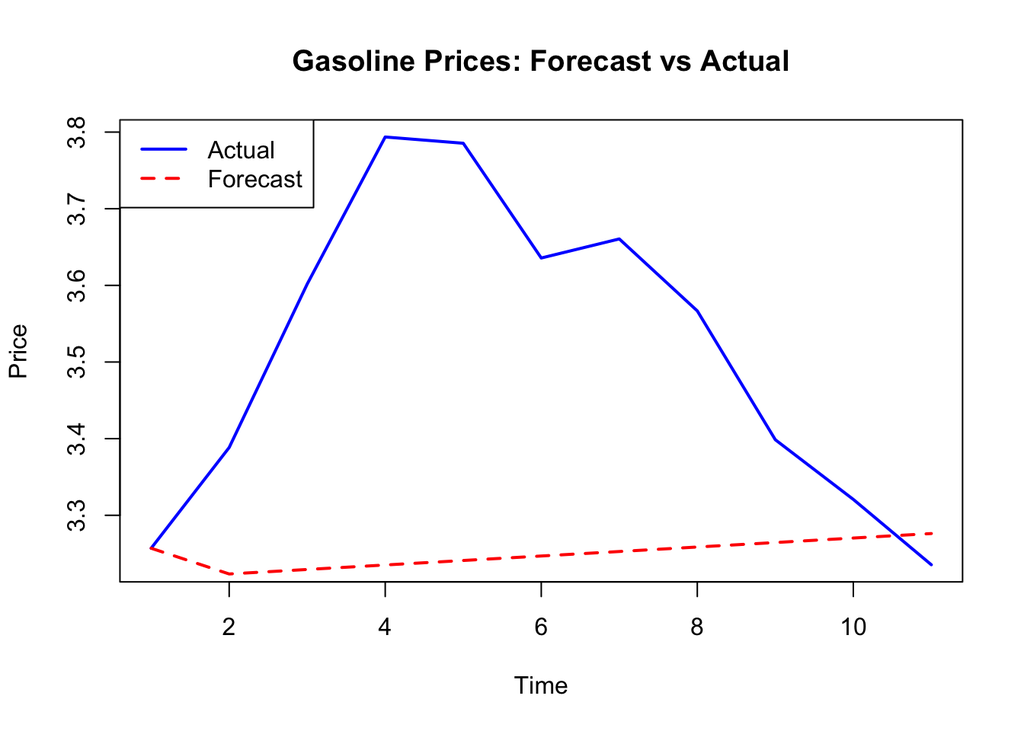

```r
# Forecast on test set
gasoline_forecast <- forecast(gasoline_model, h = length(test_gasoline_diff))
crude_forecast <- forecast(crude_model, h = length(test_crude_diff))

# Convert differenced forecasts back to actual prices
actual_gasoline_prices <- cumsum(c(last(train_gasoline), test_gasoline_diff))
forecasted_gasoline_prices <- cumsum(c(last(train_gasoline), gasoline_forecast$mean))

actual_crude_prices <- cumsum(c(last(train_crude), test_crude_diff))
forecasted_crude_prices <- cumsum(c(last(train_crude), crude_forecast$mean))

# Plot
plot(actual_gasoline_prices, type="l", col="blue", lwd=2, ylab="Price", xlab="Time", main="Gasoline Prices: Forecast vs Actual")
lines(forecasted_gasoline_prices, col="red", lwd=2, lty=2)
legend("topleft", legend=c("Actual", "Forecast"), col=c("blue", "red"), lwd=2, lty=c(1,2))
```

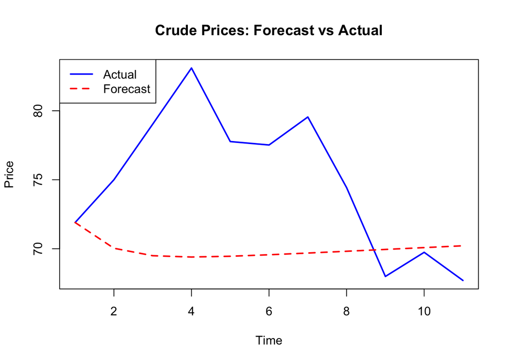

```r
# Plot
plot(actual_crude_prices, type="l", col="blue", lwd=2, ylab="Price", xlab="Time", main="Crude Prices: Forecast vs Actual")
lines(forecasted_crude_prices, col="red", lwd=2, lty=2)
legend("topleft", legend=c("Actual", "Forecast"), col=c("blue", "red"), lwd=2, lty=c(1,2))
```

### Key Takeaways

The ARIMA model struggles to accurately forecast crude oil and gasoline prices, producing a stagnant forecast while actual prices fluctuate up and down. This limitation arises because ARIMA relies solely on past price data, ignoring external factors that influence price movements. To improve forecasting performance, we can incorporate exogenous variables using ARIMAX and assess whether it captures these fluctuations more effectively.

```r
# Select the exogenous variables
exog_vars <- data[, c("U.S. Percent Utilization of Refinery Operable Capacity %",
                      "Avg of US Ending Stock of Motor Gasoline",
                      "Average of U.S. Ending Stocks excluding SPR of Crude Oil",
                      "U.S. Product Supplied of Finished Motor Gasoline",
                      "Heating Degree Days",
                      "Cooling Degree Days")]

# Make it a time series object
exog_ts <- ts(exog_vars, start = c(year(min(data$Date)), month(min(data$Date))), frequency = 12)

# Training data (1993-04 to 2023-12)
train_exog <- window(exog_ts, start = c(1993, 4), end = c(2023, 12))

# Testing data (2024-01 to 2024-11)
test_exog <- window(exog_ts, start = c(2024, 1), end = c(2024, 11))
```

Since we are introducing different variables to the model for ARIMAX, we need to ensure the new time series with exogenous variables is also stationary to proceed with modelling.

```r
# Check for stationarity
apply(train_exog, 2, adf.test)
```

```
## $`U.S. Percent Utilization of Refinery Operable Capacity %`
##
##  Augmented Dickey-Fuller Test
##
## data:  newX[, i]
## Dickey-Fuller = -4.1818, Lag order = 7, p-value = 0.01
## alternative hypothesis: stationary
##
##
## $`Avg of US Ending Stock of Motor Gasoline`
##
##  Augmented Dickey-Fuller Test
##
## data:  newX[, i]
## Dickey-Fuller = -1.6398, Lag order = 7, p-value = 0.729
## alternative hypothesis: stationary
##
##
## $`Average of U.S. Ending Stocks excluding SPR of Crude Oil`
##
##  Augmented Dickey-Fuller Test
##
## data:  newX[, i]
## Dickey-Fuller = -2.557, Lag order = 7, p-value = 0.3419
## alternative hypothesis: stationary
##
##
## $`U.S. Product Supplied of Finished Motor Gasoline`
##
##  Augmented Dickey-Fuller Test
##
## data:  newX[, i]
## Dickey-Fuller = -2.7999, Lag order = 7, p-value = 0.2393
## alternative hypothesis: stationary
##
##
## $`Heating Degree Days`
##
##  Augmented Dickey-Fuller Test
##
## data:  newX[, i]
## Dickey-Fuller = -18.843, Lag order = 7, p-value = 0.01
## alternative hypothesis: stationary
##
##
## $`Cooling Degree Days`
##
##  Augmented Dickey-Fuller Test
##
## data:  newX[, i]
## Dickey-Fuller = -25.797, Lag order = 7, p-value = 0.01
## alternative hypothesis: stationary
```

### Inference

A p-val < 0.05 for the ADF Test indicates a stationary series. Keeping that in mind we can if any of the variiables require differencing.

Stationary:

- U.S. Percent Utilization of Refinery Operable Capacity (p = 0.01)
- Heating Degree Days (p = 0.01)
- Cooling Degree Days (p = 0.01)

Non-Stationary:

- Avg of U.S. Ending Stock of Motor Gasoline (p = 0.729)
- Average of U.S. Ending Stocks excluding SPR of Crude Oil (p = 0.34)
- U.S. Product Supplied of Finished Motor Gasoline (p = 0.24)

Since there are variables that have non-stationary time series, we need to difference our time series.

```r
# Apply first order differencing
train_exog_diff <- diff(train_exog, differences=1)
test_exog_diff <- diff(test_exog, differences=1)

# Check stationarity again
apply(train_exog_diff, 2, adf.test)
```

```
## $`U.S. Percent Utilization of Refinery Operable Capacity %`
##
##  Augmented Dickey-Fuller Test
##
## data:  newX[, i]
## Dickey-Fuller = -9.2063, Lag order = 7, p-value = 0.01
## alternative hypothesis: stationary
##
##
## $`Avg of US Ending Stock of Motor Gasoline`
##
##  Augmented Dickey-Fuller Test
##
## data:  newX[, i]
## Dickey-Fuller = -8.395, Lag order = 7, p-value = 0.01
## alternative hypothesis: stationary
##
##
## $`Average of U.S. Ending Stocks excluding SPR of Crude Oil`
##
##  Augmented Dickey-Fuller Test
##
## data:  newX[, i]
## Dickey-Fuller = -7.9473, Lag order = 7, p-value = 0.01
## alternative hypothesis: stationary
##
##
## $`U.S. Product Supplied of Finished Motor Gasoline`
##
##  Augmented Dickey-Fuller Test
##
## data:  newX[, i]
## Dickey-Fuller = -11.722, Lag order = 7, p-value = 0.01
## alternative hypothesis: stationary
##
##
## $`Heating Degree Days`
##
##  Augmented Dickey-Fuller Test
##
## data:  newX[, i]
## Dickey-Fuller = -21.313, Lag order = 7, p-value = 0.01
## alternative hypothesis: stationary
##
##
## $`Cooling Degree Days`
##
##  Augmented Dickey-Fuller Test
##
## data:  newX[, i]
## Dickey-Fuller = -20.625, Lag order = 7, p-value = 0.01
## alternative hypothesis: stationary
```

### Inference

Here we can see that the p-value for all the variables are now less than 0.05, meaning that they are stationary. We can now proceed with our ARIMAX model.

```r
# Fit ARIMAX model for gasoline and crude oil prices
arimax_model_gasoline <- auto.arima(train_gasoline_diff, xreg = train_exog_diff)
arimax_model_crude <- auto.arima(train_crude_diff, xreg = train_exog_diff)

# Forecasting
arimax_forecast_gasoline <- forecast(arimax_model_gasoline, xreg = test_exog_diff)
arimax_forecast_crude <- forecast(arimax_model_crude, xreg = test_exog_diff)

# Preparing data for plotting and accuracy metrics
forecasted_gasoline_prices <- diffinv(arimax_forecast_gasoline$mean, xi = last(train_gasoline))
forecasted_crude_prices <- diffinv(arimax_forecast_crude$mean, xi = last(train_crude))
```

```r
# Compute residuals
residuals_gasoline <- test_gasoline - forecasted_gasoline_prices
residuals_crude <- test_crude - forecasted_crude_prices

# Mean Absolute Error (MAE)
mae_gasoline <- mean(abs(residuals_gasoline), na.rm = TRUE)
mae_crude <- mean(abs(residuals_crude), na.rm = TRUE)

# Root Mean Squared Error (RMSE)
rmse_gasoline <- sqrt(mean(residuals_gasoline^2, na.rm = TRUE))
rmse_crude <- sqrt(mean(residuals_crude^2, na.rm = TRUE))

# Mean Absolute Percentage Error (MAPE)
mape_gasoline <- mean(abs(residuals_gasoline / test_gasoline), na.rm = TRUE) * 100
mape_crude <- mean(abs(residuals_crude / test_crude), na.rm = TRUE) * 100

# R-squared
r_squared_gasoline <- cor(test_gasoline, forecasted_gasoline_prices, use = "complete.obs")^2
r_squared_crude <- cor(test_crude, forecasted_crude_prices, use = "complete.obs")^2

# Directional Accuracy (DA) - Fixed
direction_actual_gasoline <- sign(diff(test_gasoline))
direction_forecast_gasoline <- sign(diff(forecasted_gasoline_prices))
da_gasoline <- mean(direction_actual_gasoline == direction_forecast_gasoline, na.rm = TRUE) * 100

direction_actual_crude <- sign(diff(test_crude))
direction_forecast_crude <- sign(diff(forecasted_crude_prices))
da_crude <- mean(direction_actual_crude == direction_forecast_crude, na.rm = TRUE) * 100

# Create accuracy tables
accuracy_gasoline <- data.frame(
  Metric = c("MAE ($/Gallon)", "RMSE ($/Gallon)", "MAPE (%)", "R-squared", "Directional Accuracy (%)"),
  Value = c(
    round(mae_gasoline, 4),
    round(rmse_gasoline, 4),
    round(mape_gasoline, 2),
    round(r_squared_gasoline, 3),
    round(da_gasoline, 2)
  )
)

accuracy_crude <- data.frame(
  Metric = c("MAE ($/Barrel)", "RMSE ($/Barrel)", "MAPE (%)", "R-squared", "Directional Accuracy (%)"),
  Value = c(
    round(mae_crude, 4),
    round(rmse_crude, 4),
    round(mape_crude, 2),
    round(r_squared_crude, 3),
    round(da_crude, 2)
  )
)

# Display accuracy tables
print("Gasoline Forecasting Accuracy:")
```

```
## [1] "Gasoline Forecasting Accuracy:"
```

```r
print(accuracy_gasoline)
```

```
##                     Metric   Value
## 1           MAE ($/Gallon)  0.1345
## 2          RMSE ($/Gallon)  0.1559
## 3                 MAPE (%)  3.8400
## 4                R-squared  0.0580
## 5 Directional Accuracy (%) 66.6700
```

```r
print("Crude Oil Forecasting Accuracy:")
```

```
## [1] "Crude Oil Forecasting Accuracy:"
```

```r
print(accuracy_crude)
```

```
##                     Metric   Value
## 1           MAE ($/Barrel)  5.1273
## 2          RMSE ($/Barrel)  5.8684
## 3                 MAPE (%)  6.5400
## 4                R-squared  0.2390
## 5 Directional Accuracy (%) 55.5600
```

### Gasoline Forecast Insights

- Forecast Accuracy: MAE of $0.13 and RMSE of $0.16 indicate low forecast errors, suggesting reasonable short-term accuracy. MAPE of 3.84% confirms this.
- Model Fit: R² of 0.058 is very low, meaning the ARIMAX model explains little of the variation in gasoline prices. This suggests that key explanatory variables may be missing or the relationship is weak.
- Directional Accuracy: At 66.67%, the model captures price movement direction reasonably well but leaves room for improvement.

### Crude Oil Forecast Insights

- Forecast Accuracy: MAE of $5.13 and RMSE of $5.87 indicate relatively high forecast errors. MAPE of 6.54% shows a higher percentage error compared to gasoline, implying greater volatility or model inefficiency.
- Model Fit: R² of 0.239 suggests the model captures some variance but still struggles to explain crude oil price fluctuations effectively.
- Directional Accuracy: At 55.56%, the model is only slightly better than random guessing in predicting price direction. This suggests that crude oil price movements are influenced by factors not well captured in the current model.

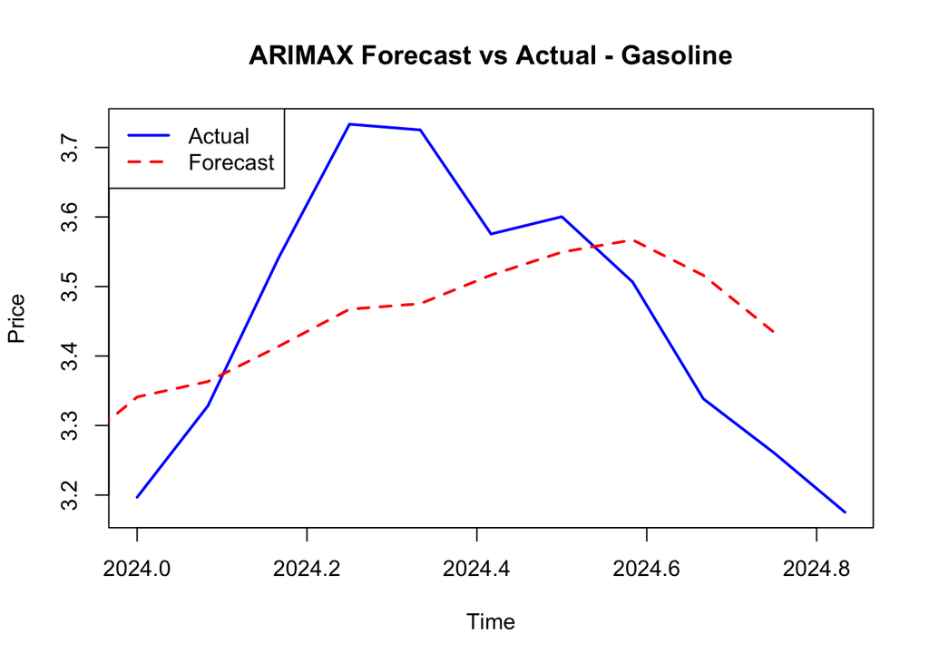

```r
# Gasoline Forecast Plot (Actual Prices)
plot(test_gasoline, type="l", col="blue", lwd=2, ylab="Price", xlab="Time",
     main="ARIMAX Forecast vs Actual - Gasoline")
lines(forecasted_gasoline_prices, col="red", lwd=2, lty=2)
legend("topleft", legend=c("Actual", "Forecast"), col=c("blue", "red"), lwd=2, lty=c(1,2))
```

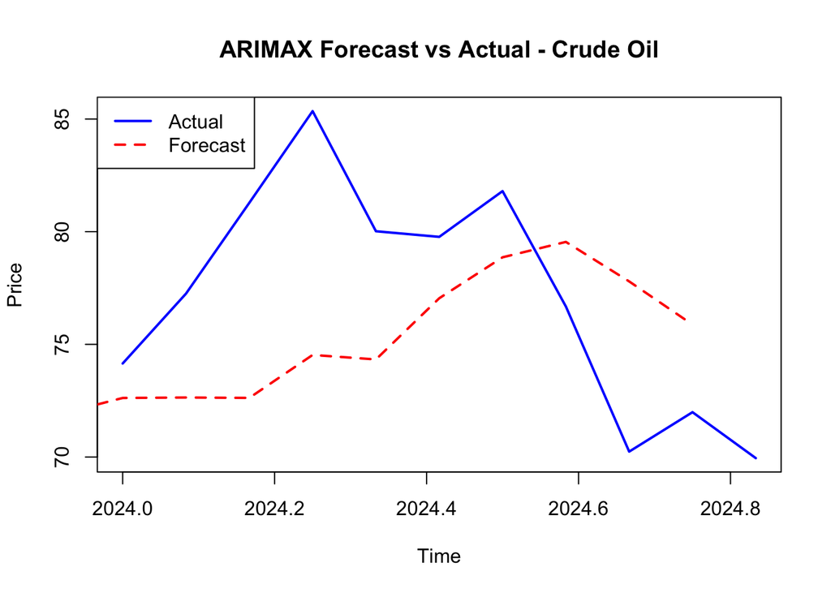

```r
# Crude Oil Forecast Plot (Actual Prices)
plot(test_crude, type="l", col="blue", lwd=2, ylab="Price", xlab="Time",
     main="ARIMAX Forecast vs Actual - Crude Oil")
lines(forecasted_crude_prices, col="red", lwd=2, lty=2)
legend("topleft", legend=c("Actual", "Forecast"), col=c("blue", "red"), lwd=2, lty=c(1,2))
```

### Key takeaways

The ARIMAX forecast shows noticeable improvement over ARIMA, as it captures some fluctuations rather than producing a flat line. However, it still lags behind actual price movements, reacting slowly to sudden spikes or drops. This suggests the model captures trend direction but struggles with responsiveness to rapid market changes.

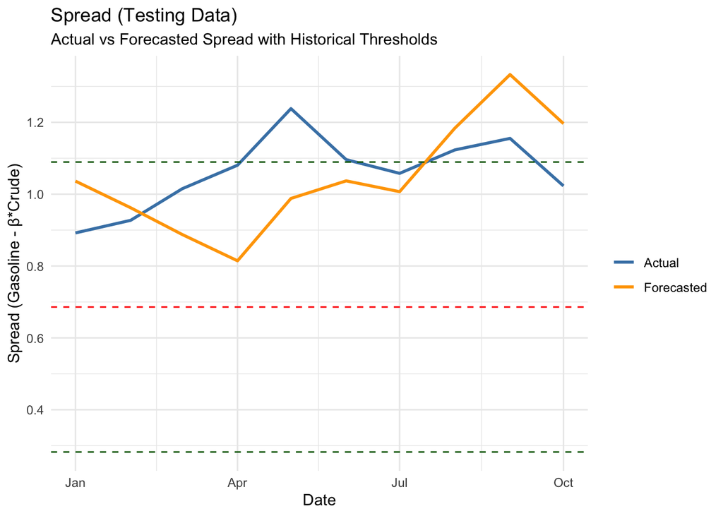

```r
# Extract the slope coefficient for calculating spread
beta_train <- coef(lm(train_gasoline ~ train_crude))[2]

# Actual spread in test set
test_spread_actual <- test_gasoline - beta_train * test_crude

# Forecasted spread using ARIMAX predictions
test_spread_forecast <- forecasted_gasoline_prices - beta_train * test_crude

# Compute historical mean and standard deviation from the training spread
historical_spread <- train_gasoline - beta_train * train_crude
historical_mean <- mean(historical_spread, na.rm = TRUE)
historical_sd <- sd(historical_spread, na.rm = TRUE)

# Combine into a dataframe
test_spread_plot_df <- data.frame(
  Date = as.Date(time(test_spread_actual))[1:(length(test_spread_actual)-1)],
  Actual = as.numeric(test_spread_actual)[1:(length(test_spread_actual)-1)],
  Forecasted = test_spread_forecast
) %>%
  pivot_longer(cols = c(Actual, Forecasted), names_to = "Type", values_to = "Spread")

# Plot testing data spread
test_spread_plot <- ggplot(test_spread_plot_df, aes(x = Date, y = Spread, color = Type)) +
  geom_line(linewidth = 1) +
  geom_hline(yintercept = historical_mean, linetype = "dashed", color = "red") +
  geom_hline(yintercept = historical_mean + 1.5*historical_sd, linetype = "dashed", color = "darkgreen") +
  geom_hline(yintercept = historical_mean - 1.5*historical_sd, linetype = "dashed", color = "darkgreen") +
  labs(
    title = "Spread (Testing Data)",
    subtitle = "Actual vs Forecasted Spread with Historical Thresholds",
    x = "Date",
    y = "Spread (Gasoline - β*Crude)",
    color = ""
  ) +
  scale_color_manual(values = c("Actual" = "steelblue", "Forecasted" = "orange")) +
  theme_minimal()

print(test_spread_plot)
```

```r
test_dates <- time(test_crude)
test_dates <- test_dates[1:length(test_spread_forecast)]

# Ensure test_spread_forecast aligns with test dates
test_df <- data.frame(
  Date = test_dates,  # Ensure this is correctly assigned
  Spread_Forecast = test_spread_forecast
)

# Compute Z-score for spread forecast
test_df <- test_df %>%
  mutate(
    Z_Score = (Spread_Forecast - historical_mean) / historical_sd
  )

# Generate Buy/Sell/Hold signals based on Z-score
test_df <- test_df %>%
  mutate(
    Signal = case_when(
      Z_Score < -1.5 ~ "Buy",
      Z_Score > 1.5 ~ "Sell",
      TRUE ~ "Hold"
    )
  )

# Align actual gasoline prices properly
test_df <- test_df %>%
  mutate(
    Gasoline_Actual = test_gasoline[-length(test_gasoline)],  # Remove last value to match
    Gasoline_Next = lead(Gasoline_Actual)  # Next-period gasoline price
  )

# Compute trading returns based on signals
test_df <- test_df %>%
  mutate(
    Returns = case_when(
      Signal == "Buy" ~ (Gasoline_Next - Gasoline_Actual) * 1000,  # Profit if price rises
      Signal == "Sell" ~ (Gasoline_Actual - Gasoline_Next) * 1000,  # Profit if price falls
      TRUE ~ 0
    )
  )

# Compute cumulative profit
test_df <- test_df %>%
  mutate(Cumulative_Profit = cumsum(coalesce(Returns, 0)))

# Compute total profit
total_profit <- sum(test_df$Returns, na.rm = TRUE)
cat("\nTotal Profit from ARIMAX Spread Strategy: $", round(total_profit, 2), "\n")
```

```
##
## Total Profit from ARIMAX Spread Strategy: $ 246
```

```r
test_df <- test_df %>%
  mutate(Date = as.Date(Date))  # Ensure Date is of type Date

colnames(test_df) <- make.names(colnames(test_df))
```

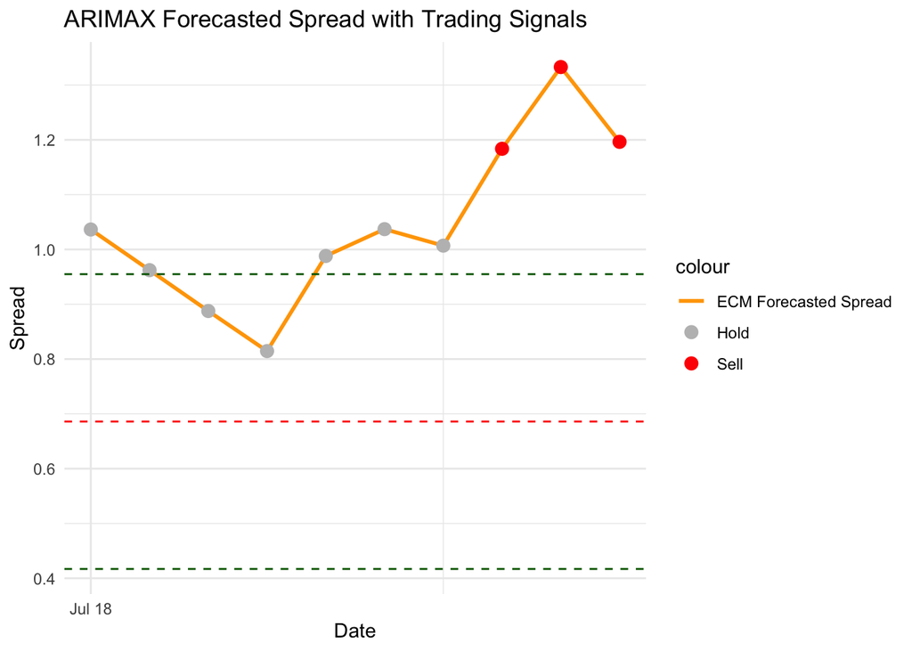

```r
# Create a dataframe for plotting
test_df <- test_df %>%
  mutate(
    Spread_Forecast = test_spread_forecast  # Rename to ensure it's recognized as a column
  )

# Create a dataframe for plotting
#plot_df <- test_df %>%
  #select(Date, Spread_Forecast, Gasoline_Actual, Signal)

plot_df <- dplyr::select(test_df, Date, Spread_Forecast, Gasoline_Actual, Signal)


# Plot Spread with Trading Signals
spread_plot <- ggplot(plot_df, aes(x = Date)) +
  geom_line(aes(y = test_spread_forecast, color = "ECM Forecasted Spread"), linewidth = 1) +  # ECM Spread Line
  geom_point(aes(y = test_spread_forecast, color = Signal), size = 3) +  # Signal points on spread
  geom_hline(yintercept = historical_mean, linetype = "dashed", color = "red") +
  geom_hline(yintercept = historical_mean + 1 * historical_sd, linetype = "dashed", color = "darkgreen") +
  geom_hline(yintercept = historical_mean - 1 * historical_sd, linetype = "dashed", color = "darkgreen") +
  labs(
    title = "ARIMAX Forecasted Spread with Trading Signals",
    x = "Date",
    y = "Spread"
  ) +
  scale_color_manual(values = c("Buy" = "green", "Sell" = "red", "Hold" = "gray", "ECM Forecasted Spread" = "orange")) +
  theme_minimal()

# Plot Actual Gasoline Price with Trading Signals
gasoline_plot <- ggplot(plot_df, aes(x = Date)) +
  geom_line(aes(y = Gasoline_Actual, color = "Actual Gasoline Price"), linewidth = 1) +  # Actual Gasoline Price Line
  geom_point(aes(y = Gasoline_Actual, color = Signal), size = 3) +  # Signal points on gasoline price
  labs(
    title = "Actual Gasoline Price with Trading Signals",
    x = "Date",
    y = "Gasoline Price"
  ) +
  scale_color_manual(values = c("Buy" = "green", "Sell" = "red", "Hold" = "gray", "Actual Gasoline Price" = "steelblue")) +
  theme_minimal()

# Print both plots
print(spread_plot)
```

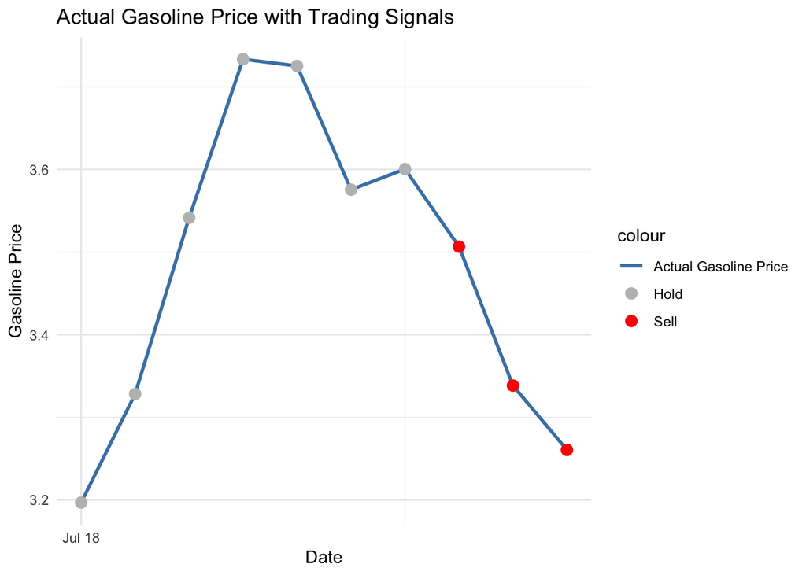

```r
print(gasoline_plot)
```

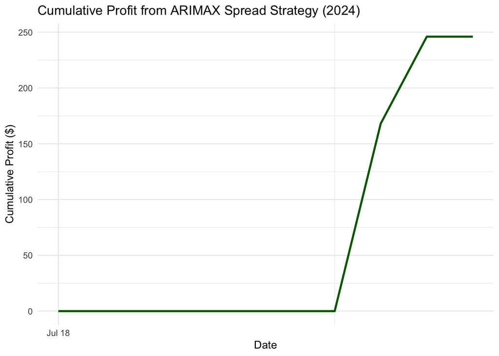

```r
# Ensure Date and Cumulative Profit columns are correctly defined
test_df <- test_df %>%
  mutate(
    Cumulative_Profit = cumsum(replace_na(Returns, 0))  # Compute cumulative profit over time
  )

# Plot cumulative profit over time
cumulative_profit_plot <- ggplot(test_df, aes(x = Date, y = Cumulative_Profit)) +
  geom_line(color = "darkgreen", linewidth = 1) +  # Profit trend line
  labs(
    title = "Cumulative Profit from ARIMAX Spread Strategy (2024)",
    x = "Date",
    y = "Cumulative Profit ($)"
  ) +
  theme_minimal()

# Print the plot
print(cumulative_profit_plot)
```